# Model 2: Condition-Specific Models

```r
# Wald summary on the rate-ratio scale, carrying three interval variants:
#   - Wald        model-based, understates uncertainty (inherited decision 10)
#   - robust      Huber-White sandwich, sees unequal weighting only
#   - Kish        Wald inflated by sqrt(design effect), applied uniformly
# NOT bootstrap: the replicate weights Section 5.7 assumes do not exist in the
# 2010 or 2014 PUMF. Inherited decisions 10 and 15.
tidy_nb <- function(nb_fit, column_map, deff = 1) {
  robust_se <- tryCatch(sqrt(diag(robust_vcov(nb_fit))), error = function(e) NULL)

  out <- summary(nb_fit)$coefficients %>%
    as.data.frame() %>%
    tibble::rownames_to_column("column") %>%
    rename(estimate = Estimate, std_error = `Std. Error`, p_value = `Pr(>|z|)`) %>%
    filter(column != "(Intercept)") %>%
    left_join(column_map, by = "column")

  out %>%
    mutate(
      se_robust = if (is.null(robust_se)) NA_real_ else unname(robust_se[column]),
      se_kish = std_error * sqrt(deff),
      p_robust = 2 * stats::pnorm(-abs(estimate / se_robust)),
      rate_ratio = exp(estimate),
      ci_low = exp(estimate - 1.96 * std_error),
      ci_high = exp(estimate + 1.96 * std_error),
      ci_low_robust = exp(estimate - 1.96 * se_robust),
      ci_high_robust = exp(estimate + 1.96 * se_robust),
      ci_low_kish = exp(estimate - 1.96 * se_kish),
      ci_high_kish = exp(estimate + 1.96 * se_kish),
      unstable = std_error > unstable_se
    )
}

# Section 5.8's C-statistic, adapted to a count outcome (inherited decision 17).
# Pairs tied on the outcome carry no information about discrimination and are
# excluded from the denominator, so the comparable share travels with the
# statistic. Returns NA rather than failing when a subgroup is too thin or too
# uniform for concordance to be defined.
harrell_c <- function(observed, predicted, weights) {
  empty <- tibble::tibble(c_statistic = NA_real_, c_se = NA_real_,
                          comparable_share = NA_real_)
  if (length(unique(observed)) < 2L || length(observed) < 3L) return(empty)
  tryCatch({
    fit <- survival::concordance(observed ~ predicted, weights = weights)
    counts <- fit$count
    comparable <- sum(counts[c("concordant", "discordant", "tied.x")])
    total <- comparable + sum(counts[c("tied.y", "tied.xy")])
    tibble::tibble(
      c_statistic = as.numeric(fit$concordance),
      c_se = sqrt(as.numeric(fit$var)),
      comparable_share = comparable / total
    )
  }, error = function(e) empty)
}

# Negative binomial log-likelihood on held-out rows, using the coefficients and
# the theta estimated on the training rows. Weighted, per inherited decision 19.
nb_loglik <- function(observed, predicted, theta, weights) {
  sum(weights * stats::dnbinom(observed, size = theta, mu = predicted, log = TRUE))
}

# Deterministic fold assignment. Every condition, specification and CV variant
# scores the same partition of its own subgroup, so differences between them are
# differences in model rather than luck of the draw.
assign_folds <- function(n, k, seed) {
  set.seed(seed)
  sample(rep_len(seq_len(k), n))
}

# One training/testing pass for a GIVEN term set. Both CV variants of Step 9
# call this; they differ only in where `term_vars` comes from.
#
# This is model-1's `evaluate_fold()` with three subgroup guards added, because
# a fifth of a two-thousand-respondent subgroup is a much thinner object than a
# fifth of the Section 5.5 sample:
#   1. terms that go constant in the training fold are dropped and counted
#   2. test rows carrying a factor level the training fold never saw are dropped
#      and counted, rather than allowed to propagate NA through the metrics
#   3. a fold whose fit fails returns a row marked `converged = FALSE` rather
#      than aborting the condition, as Section 5.7 requires
evaluate_fold <- function(frame, train_rows, test_rows, term_vars, outcome) {
  failed <- tibble::tibble(
    n_train = length(train_rows), n_test = length(test_rows), n_unscorable = NA_integer_,
    n_terms = NA_integer_, theta = NA_real_, converged = FALSE,
    rmse = NA_real_, mae = NA_real_, loglik = NA_real_, mcfadden_r2 = NA_real_,
    c_statistic = NA_real_, c_se = NA_real_, comparable_share = NA_real_
  )

  train <- droplevels(frame[train_rows, , drop = FALSE])
  test <- frame[test_rows, , drop = FALSE]

  term_vars <- term_vars[purrr::map_lgl(term_vars, ~ is_informative(train[[.x]]))]

  factor_terms <- term_vars[purrr::map_lgl(term_vars, ~ is.factor(train[[.x]]))]
  scorable <- rep(TRUE, nrow(test))
  for (this_var in factor_terms) {
    scorable <- scorable & as.character(test[[this_var]]) %in% levels(train[[this_var]])
  }
  n_dropped <- sum(!scorable)
  test <- test[scorable, , drop = FALSE]
  if (nrow(test) < 3L) return(failed)
  for (this_var in factor_terms) {
    test[[this_var]] <- factor(as.character(test[[this_var]]),
                               levels = levels(train[[this_var]]))
  }

  fit <- fit_nb(train, term_vars, outcome)
  fit_null <- fit_nb(train, character(0), outcome)
  if (is.null(fit) || is.null(fit_null)) return(failed)

  predicted <- tryCatch(stats::predict(fit, newdata = test, type = "response"),
                        error = function(e) NULL)
  if (is.null(predicted) || anyNA(predicted)) return(failed)
  predicted_null <- stats::predict(fit_null, newdata = test, type = "response")
  observed <- test[[outcome]]
  w <- test$weight_scaled

  loglik_test <- nb_loglik(observed, predicted, fit$theta, w)
  loglik_test_null <- nb_loglik(observed, predicted_null, fit_null$theta, w)

  dplyr::bind_cols(
    tibble::tibble(
      n_train = nrow(train),
      n_test = nrow(test),
      n_unscorable = n_dropped,
      n_terms = length(stats::coef(fit)) - 1L,
      theta = fit$theta,
      converged = isTRUE(fit$converged),
      rmse = sqrt(stats::weighted.mean((observed - predicted)^2, w)),
      mae = stats::weighted.mean(abs(observed - predicted), w),
      loglik = loglik_test,
      mcfadden_r2 = 1 - loglik_test / loglik_test_null
    ),
    harrell_c(observed, predicted, w)
  )
}
```

```r
# Cut a condition subgroup out of its frame and re-scale its weights to mean 1
# (decision 30). Unused factor levels are dropped here, once, so that every
# downstream step sees the same subgroup.
build_subgroup <- function(frame, condition_var) {
  frame %>%
    filter(.data[[condition_var]] == "Yes") %>%
    droplevels() %>%
    mutate(weight_scaled = .data[[weight_col]] / mean(.data[[weight_col]]))
}

# The candidate set offered to the penalty inside one subgroup (decisions 23
# and 24): the primary Section 5.5 predictor set, minus the index condition,
# minus anything that has gone constant. The other sixteen conditions stay.
subgroup_candidates <- function(subgroup, condition_var, candidates) {
  offered <- setdiff(candidates, condition_var)
  offered[purrr::map_lgl(offered, ~ is_informative(subgroup[[.x]]))]
}

# The whole stage-one pipeline for one condition, from frame to cross-validated
# penalised fit. Returns everything the later steps need, including what it had
# to drop, so that Table t2 can report the cost of the subgroup restriction.
fit_condition <- function(condition_var) {
  frame_id <- fitted_conditions$frame[fitted_conditions$variable == condition_var]
  subgroup <- build_subgroup(frames[[frame_id]], condition_var)

  offered <- subgroup_candidates(subgroup, condition_var, vars_excluding_perceived)
  dropped <- setdiff(setdiff(vars_excluding_perceived, condition_var), offered)
  forced_here <- forced_vars[purrr::map_lgl(forced_vars, ~ is_informative(subgroup[[.x]]))]

  feasible <- nrow(subgroup) >= min_fit_n && length(offered) > 0
  design <- if (feasible) build_design(subgroup, c(forced_here, offered)) else NULL
  lasso <- if (feasible) {
    tryCatch(
      fit_lasso(design, subgroup[[outcome_var]], subgroup$weight_scaled, lasso_seed),
      error = function(e) NULL
    )
  } else {
    NULL
  }

  list(
    condition = condition_var,
    frame_id = frame_id,
    subgroup = subgroup,
    offered = offered,
    dropped = dropped,
    forced = forced_here,
    design = design,
    lasso = lasso,
    kish_deff = kish_design_effect(subgroup[[weight_col]])
  )
}
```

# Data

**Load the Ellis respondent-level analytical parquet**

```r
ds0 <- arrow::read_parquet(path_parquet)
```

**Build the two complete-case frames and the label lookups**

```r
# Two frames, recoded identically (decisions 21 and 22).
#
#   ds1   the model-1 complete-case frame: complete on the 48 LASSO candidates.
#         Sixteen of the seventeen condition subgroups are cut from it, so every
#         one of them is a strict subset of the Section 5.5 analytic sample.
#
#   ds2   the same, additionally complete on cc_copd. Because the COPD question
#         is administered only from age 35, requiring it is what restricts the
#         frame; no explicit age filter is applied or needed. This frame exists
#         only to host the COPD subgroup.
ds_model_raw <- prepare_frame()

n_source <- nrow(ds_model_raw)
complete_flag <- stats::complete.cases(ds_model_raw)

ds1 <- ds_model_raw %>%
  filter(complete_flag) %>%
  mutate(.respondent_id = dplyr::row_number())

ds_copd_raw <- prepare_frame(copd_var)
ds2 <- ds_copd_raw %>%
  filter(stats::complete.cases(.)) %>%
  mutate(.respondent_id = dplyr::row_number())

frames <- list(main = ds1, age35 = ds2)

n_analytic <- nrow(ds1)
n_analytic_copd <- nrow(ds2)

variable_labels <- c(
  stats::setNames(candidate_registry$variable_label, candidate_registry$variable),
  stats::setNames("CCHS cycle", cycle_var)
)
variable_domains <- c(
  stats::setNames(candidate_registry$domain, candidate_registry$variable),
  stats::setNames("Survey design", cycle_var)
)
condition_labels <- stats::setNames(
  variable_labels[fitted_conditions$variable], fitted_conditions$variable
)
```

```
Rows: 63,843
Columns: 70
$ cchs_cycle               <int> 0, 0, 0, 0, 0, 0, 0, 0, 0, 0, 0, 0, 0, 0, 0, 0, 0, 0, 0, 0, 0, 0,…
$ cchs_cycle_f             <fct> 2010-2011, 2010-2011, 2010-2011, 2010-2011, 2010-2011, 2010-2011,…
$ wts_m                    <dbl> 293.76, 743.82, 2984.93, 975.96, 387.17, 415.98, 178.10, 472.60, …
$ wts_m_pooled             <dbl> 146.880, 371.910, 1492.465, 487.980, 193.585, 207.990, 89.050, 23…
$ days_absent_total        <dbl> 0, 1, 0, 5, 0, 0, 0, 0, 0, 0, 0, 0, 2, 3, 0, 0, 0, 0, 0, 2, 0, 0,…
$ days_absent_chronic      <dbl> 0, 1, 0, 4, 0, 0, 0, 0, 0, 0, 0, 0, 0, 0, 0, 0, 0, 0, 0, 0, 0, 0,…
$ lopg040                  <dbl> 0, 1, 0, 4, 0, 0, 0, 0, 0, 0, 0, 0, 0, 0, 0, 0, 0, 0, 0, 0, 0, 0,…
$ lopg070                  <dbl> 0, 0, 0, 0, 0, 0, 0, 0, 0, 0, 0, 0, 0, 0, 0, 0, 0, 0, 0, 0, 0, 0,…
$ lopg082                  <dbl> 0, 0, 0, 1, 0, 0, 0, 0, 0, 0, 0, 0, 0, 0, 0, 0, 0, 0, 0, 2, 0, 0,…
$ lopg083                  <dbl> 0, 0, 0, 0, 0, 0, 0, 0, 0, 0, 0, 0, 0, 3, 0, 0, 0, 0, 0, 0, 0, 0,…
$ lopg084                  <dbl> 0, 0, 0, 0, 0, 0, 0, 0, 0, 0, 0, 0, 2, 0, 0, 0, 0, 0, 0, 0, 0, 0,…
$ lopg085                  <dbl> 0, 0, 0, 0, 0, 0, 0, 0, 0, 0, 0, 0, 0, 0, 0, 0, 0, 0, 0, 0, 0, 0,…
$ lopg086                  <dbl> 0, 0, 0, 0, 0, 0, 0, 0, 0, 0, 0, 0, 0, 0, 0, 0, 0, 0, 0, 0, 0, 0,…
```

[output cut: 57 more lines]

# Data Context

For complete data documentation, see the Data Primer. This section covers only what Model 2 touches. The estimation that Model 2 extends is documented in Model 1.

## Tables and columns

```
Source table: ./data-private/derived/cchs-2-tables/cchs_analytic.parquet
```

```
  grain:      one row per respondent, two pooled CCHS cycles
```

```
  rows:       63,843
```

```
  columns:    70
```

```
Columns this report draws on:
```

```
  outcome:      days_absent_total
```

```
  weight:       wts_m_pooled (master weight halved for pooling, rescaled within each subgroup)
```

```
  forced in:    cchs_cycle_f
```

```
  subgrouping:  17 chronic-condition indicators
```

```
  candidates:   45 offered inside each subgroup, less the index condition
```

```
The two analytic frames:
```

```
         frame                          definition   rows                  hosts
    main (ds1) complete on the 48 LASSO candidates 48,932 16 condition subgroups
 age 35+ (ds2)  the same, plus complete on cc_copd 48,932 the COPD subgroup only
```

## A single respondent

One row from a condition subgroup, shown in full. Two things are worth checking in it: that a row is a person, and that the index condition reads `Yes` — which is the whole reason it is removed from that model’s candidate set.

```
Grain proof
```

```
  rows in source:         63,843
```

```
  rows in main frame:     48,932
```

```
  rows in age 35+ frame:  48,932
```

```
  duplicated ids (main):  0
```

```
One respondent from the Arthritis subgroup (n = 6,552):
```

```
           Domain                        Variable                         Value
 Outcome / design               days_absent_total                             0
 Outcome / design                    wts_m_pooled                       390.645
 Outcome / design                    cchs_cycle_f                     2010-2011
         Exposure                          Asthma                            No
         Exposure                    Fibromyalgia                            No
         Exposure   Arthritis  <- index condition                           Yes
         Exposure                   Back problems                           Yes
         Exposure                    Hypertension                            No
         Exposure                        Migraine                            No
         Exposure                        Diabetes                            No
         Exposure                   Heart disease                            No
         Exposure                          Cancer                            No
         Exposure      Stomach / intestinal ulcer                            No
         Exposure                          Stroke                            No
         Exposure                  Bowel disorder                            No
         Exposure        Chronic fatigue syndrome                            No
         Exposure Multiple chemical sensitivities                            No
         Exposure                   Mood disorder                            No
         Exposure                Anxiety disorder                            No
     Predisposing                       Age group                         25-54
     Predisposing                             Sex                          Male
     Predisposing                  Marital status                       Married
     Predisposing                  Household size                     2 persons
     Predisposing     Child aged 0-5 in household                            No
     Predisposing    Child aged 6-11 in household                            No
     Predisposing                       Education           Some post-secondary
     Predisposing              Immigration status Non-immigrant (Canadian-born)
     Predisposing                Visible minority                         White
     Predisposing                  Home ownership                         Owner
     Predisposing             Living arrangements           Couple, no children
     Facilitating                Household income             $60,000 - $79,999
     Facilitating                        Province                            QC
     Facilitating                 Employment type                      Employee
     Facilitating                   Work schedule                     Full-time
     Facilitating             Occupation category              Sales / Services
     Facilitating                  Smoking status                        Former
     Facilitating                    BMI category                         Obese
     Facilitating               Physical activity                      Inactive
     Facilitating             Alcohol consumption               Regular drinker
     Facilitating      Fruit / vegetable servings           Less than 5 per day
     Facilitating                     Work stress            Not very stressful
            Needs   Self-perceived general health                          Good
            Needs    Self-perceived mental health                     Excellent
            Needs            Health vs prior year                About the same
            Needs       Injured in past 12 months                            No
            Needs               Needs help: meals                            No
            Needs             Needs help: errands                            No
            Needs           Needs help: housework                            No
            Needs       Needs help: personal care                            No
            Needs      Needs help: moving indoors                            No
            Needs            Needs help: finances                            No
```

```
The index condition reads 'Yes' by construction, which is precisely why it
```

```
is removed from the candidate set inside its own subgroup (decision 23).
```

## Distributions

The outcome is shown *inside* subgroups rather than in the pooled sample, because that is what the Section 5.7 models are fitted to and the two are not the same shape.

```
Outcome: days_absent_total (days, capped at 90 in Ellis)
```

```
                       Condition     n Mean days (wtd) Variance (wtd) Var / mean Zero days Max
                   Back problems 9,044           2.131          28.72      13.47     61.2%  63
                    Hypertension 7,017           1.679          23.97      14.27     69.5%  52
                       Arthritis 6,552           2.318          35.36      15.25     64.6%  62
                        Migraine 5,162           2.429          33.75      13.89     54.9%  61
                          Asthma 3,853           1.954          24.36      12.47     59.2%  62
                   Mood disorder 3,296           3.370          52.49      15.57     49.2%  61
                Anxiety disorder 2,670           2.716          40.47      14.90     51.1%  61
                  Bowel disorder 2,372           2.696          35.52      13.17     53.9%  45
                        Diabetes 2,329           1.801          27.85      15.46     67.6%  52
                   Heart disease 1,364           2.338          35.89      15.35     67.5%  40
 Multiple chemical sensitivities 1,279           2.438          38.02      15.59     54.7%  61
      Stomach / intestinal ulcer 1,123           2.837          39.94      14.08     58.3%  42
                            COPD   932           3.305          48.24      14.60     57.8%  61
                    Fibromyalgia   590           2.713          44.81      16.52     53.9%  52
                          Cancer   559           3.566          51.71      14.50     55.6%  52
        Chronic fatigue syndrome   438           4.576          70.36      15.38     47.5%  52
                          Stroke   187           2.735          37.99      13.89     57.8%  34
```

```
Equidispersion would put variance / mean at 1. No subgroup is close, so
```

```
stage two is negative binomial in every one of them, exactly as in model-1.
```

```
Note also that the zero share stays high inside every subgroup: conditioning
```

```
on a chronic condition does not turn this into a dense count outcome.
```

**Reading the subgroup outcome summary**

Two features govern everything downstream. The variance-to-mean ratio stays far above 1 in every subgroup, so stage two is negative binomial throughout, exactly as in model-1. And the share of respondents at zero days stays high even after conditioning on a chronic condition — selecting on disease raises the mean but does not make this a dense count. That second fact is why the C-statistic in Step 9 is a narrow instrument here, and why RMSE moves in directions that likelihood-based measures do not.

# Analysis

## Step 1 — The Condition Roster

Section 5.7 says “each of the 19 chronic conditions.” Establishing what those nineteen are, in terms of items that exist in the 2010 and 2014 Public Use Microdata Files, is the first substantive act of the report — and it does not come out to nineteen.

Table t1: Condition roster. The 19 constructs Section 2.2 names, mapped onto the items the CCC module of the 2010 and 2014 PUMF carries. Two of them are not separately available, so Section 5.7’s nineteen models resolve to 17 (decision 20).

| # | Condition (Section 2.2) | CCHS variable | Frame | Status | Note |
| --- | --- | --- | --- | --- | --- |
| 1 | Arthritis | cc_arthritis | main | fitted |  |
| 2 | Asthma | cc_asthma | main | fitted |  |
| 3 | Cardiovascular disease | cc_heart_disease | main | fitted | Section 2.2 pairs this with stroke; the CCC module carries them as two items and they are modelled separately. |
| 4 | Stroke | cc_stroke | main | fitted | See row 3. The rarest condition in the roster; read its model against the n in Table t2. |
| 5 | Hypertension | cc_hypertension | main | fitted |  |
| 6 | Fibromyalgia | cc_fibromyalgia | main | fitted |  |
| 7 | Diabetes | cc_diabetes | main | fitted |  |
| 8 | Migraine | cc_migraine | main | fitted |  |
| 9 | Back problems | cc_back_problems | main | fitted |  |
| 10 | Cancer | cc_cancer | main | fitted |  |
| 11 | COPD | cc_copd | age 35+ | fitted | Administered only to respondents aged 35 and over, so it is fitted on the supplementary frame. Decision 21. |
| 12 | Mental illness (depression, bipolar) | cc_mood_disorder | main | SAME ITEM as row 17 | The CCC module asks a single mood-disorder question covering depression, bipolar disorder, mania and dysthymia. Identical to row 17; modelled once. |
| 13 | Bowel disorders | cc_bowel_disorder | main | fitted |  |
| 14 | Digestive diseases | — | — | NO PUMF ITEM | No CCC item distinct from bowel disorder exists in either cycle’s PUMF. |
| 15 | Chronic fatigue syndrome | cc_fatigue_syndrome | main | fitted | Named in Section 5.7 as a subgroup expected to be small. |
| 16 | Multiple chemical sensitivities | cc_chem_sensitivity | main | fitted | Named in Section 5.7 as a subgroup expected to be small. |
| 17 | Mood disorder | cc_mood_disorder | main | fitted | The item that also answers row 12. |
| 18 | Anxiety disorder | cc_anxiety | main | fitted |  |
| 19 | Stomach or intestinal ulcer | cc_ulcer | main | fitted |  |

Two rows of the roster do not survive the mapping. “Mental illness (depression, bipolar)” and “mood disorder” are the same CCC question — the module asks one item covering depression, bipolar disorder, mania and dysthymia — so they yield one model, not two. “Digestive diseases” has no item distinct from bowel disorder in either cycle. A third row, COPD, exists but is asked only of respondents aged 35 and over, and is handled by giving it a frame of its own.

Table t11: Condition subgroup inventory. Both sample sizes Section 5.7 asks for - unweighted n and weighted N - plus the count that actually limits a count model, the number of respondents reporting at least one day absent (decision 26). The design effect is computed within each subgroup (decision 29).

| Condition | Frame | n | Weighted N | Prevalence in frame | n with >= 1 day | % with >= 1 day | Mean days (wtd) | Kish deff | Sec 5.7 flag |
| --- | --- | --- | --- | --- | --- | --- | --- | --- | --- |
| Back problems | main | 9,044 | 2,404,140 | 18.48% | 3,510 | 38.8% | 2.13 | 3.84 |  |
| Hypertension | main | 7,017 | 1,654,969 | 14.34% | 2,142 | 30.5% | 1.68 | 4.22 |  |
| Arthritis | main | 6,552 | 1,445,511 | 13.39% | 2,322 | 35.4% | 2.32 | 4.01 |  |
| Migraine | main | 5,162 | 1,414,397 | 10.55% | 2,330 | 45.1% | 2.43 | 3.20 |  |
| Asthma | main | 3,853 | 1,064,748 | 7.87% | 1,571 | 40.8% | 1.95 | 3.49 |  |
| Mood disorder | main | 3,296 | 831,166 | 6.74% | 1,674 | 50.8% | 3.37 | 3.19 |  |
| Anxiety disorder | main | 2,670 | 707,707 | 5.46% | 1,306 | 48.9% | 2.72 | 3.34 |  |
| Bowel disorder | main | 2,372 | 571,139 | 4.85% | 1,094 | 46.1% | 2.70 | 3.03 |  |
| Diabetes | main | 2,329 | 559,717 | 4.76% | 754 | 32.4% | 1.80 | 3.81 |  |
| Heart disease | main | 1,364 | 298,377 | 2.79% | 443 | 32.5% | 2.34 | 3.14 |  |
| Multiple chemical sensitivities | main | 1,279 | 301,153 | 2.61% | 579 | 45.3% | 2.44 | 3.68 |  |
| Stomach / intestinal ulcer | main | 1,123 | 320,726 | 2.30% | 468 | 41.7% | 2.84 | 3.69 |  |
| COPD | age 35+ | 932 | 194,850 | 1.90% | 393 | 42.2% | 3.30 | 4.39 |  |
| Fibromyalgia | main | 590 | 152,033 | 1.21% | 272 | 46.1% | 2.71 | 4.23 |  |
| Cancer | main | 559 | 122,184 | 1.14% | 248 | 44.4% | 3.57 | 3.18 |  |
| Chronic fatigue syndrome | main | 438 | 103,679 | 0.90% | 230 | 52.5% | 4.58 | 2.68 | n < 500 |
| Stroke | main | 187 | 35,814 | 0.38% | 79 | 42.2% | 2.74 | 2.27 | n < 500 |

Table t11 carries both sample sizes Section 5.7 asks for — unweighted $n$ and weighted $N$ — and one it does not: the number of respondents in each subgroup reporting at least one day absent. That third column is the one to read. A negative binomial model of a count outcome learns from variation in the count, and a subgroup of a thousand respondents of whom two hundred have a non-zero outcome is a thinner object than its $n$ suggests.

**Review point 1**

Agree or disagree with the mapping in Table t1. Three specific questions:

1. Is collapsing “mental illness” and “mood disorder” into the single CCC item correct, or was a separate construct intended that would require a different data source?
2. Section 2.2 pairs “cardiovascular disease/stroke” as one construct. The CCC module carries heart disease and stroke as separate items and they are modelled separately here. Should they instead be combined into one subgroup?
3. Is “digestive diseases” genuinely absent, or is it meant to denote the bowel-disorder item under another name?

## Step 2 — Subgroup Feasibility

Section 5.7 anticipates that some subgroups will be small and asks for them to be flagged at $n < 500$. That threshold is necessary but not sufficient, because what a selection procedure needs is not respondents but respondents *per parameter*.

**Compute per-subgroup candidate counts, design width, and verdicts**

```r
feasibility <- purrr::map_dfr(fitted_conditions$variable, function(this_condition) {
  frame_id <- fitted_conditions$frame[fitted_conditions$variable == this_condition]
  sub <- build_subgroup(frames[[frame_id]], this_condition)
  offered <- subgroup_candidates(sub, this_condition, vars_excluding_perceived)
  dropped <- setdiff(setdiff(vars_excluding_perceived, this_condition), offered)
  forced_here <- forced_vars[purrr::map_lgl(forced_vars, ~ is_informative(sub[[.x]]))]
  n_columns <- if (length(offered) > 0) {
    ncol(build_design(sub, c(forced_here, offered))$x)
  } else {
    0L
  }
  tibble::tibble(
    condition = this_condition,
    n = nrow(sub),
    n_nonzero = sum(sub[[outcome_var]] > 0),
    n_offered = length(offered),
    n_dropped = length(dropped),
    dropped_vars = paste(variable_labels[dropped], collapse = "; "),
    n_columns = n_columns
  )
}) %>%
  mutate(
    condition_label = variable_labels[condition],
    per_column = n / pmax(n_columns, 1L),
    nonzero_per_column = n_nonzero / pmax(n_columns, 1L),
    verdict = dplyr::case_when(
      n < min_fit_n ~ "not fitted",
      n < small_subgroup_n ~ "fitted, flagged small",
      TRUE ~ "fitted"
    )
  ) %>%
  arrange(desc(n))

readr::write_csv(feasibility, paste0(local_data, "subgroup-feasibility.csv"))
```

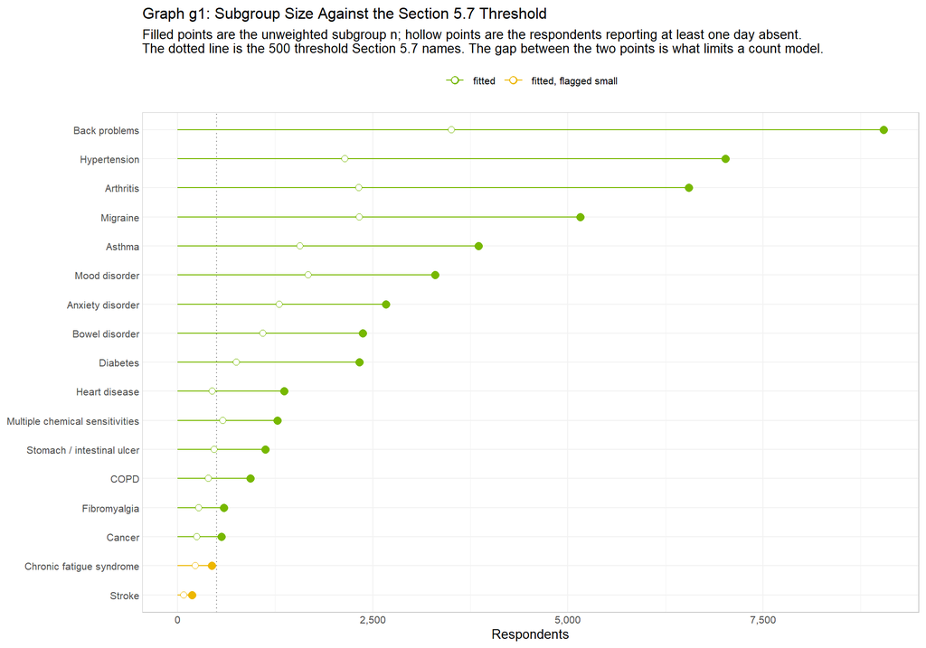

The two point series in Graph g1 are the story of this report. The filled points are the subgroup sizes Section 5.7 asks about; the hollow points are the respondents who actually contribute variation to a count model. The gap between them is roughly constant in proportion and large in every subgroup.

Table t2: Subgroup feasibility ledger. ‘Dropped as constant’ counts candidate variables that lose all but one level inside the subgroup and so cannot be dummy-coded (decision 23); the index condition is removed separately and is not counted here. The last column is the honest measure of how much a subgroup can support: a penalty is what makes estimation possible at all when it falls below one.

| Condition | n | n with >= 1 day | Candidates offered | Dropped as constant | Design columns | Respondents per column | Non-zero per column | Verdict |
| --- | --- | --- | --- | --- | --- | --- | --- | --- |
| Back problems | 9,044 | 3,510 | 44 | 0 | 85 | 106.4 | 41.3 | fitted |
| Hypertension | 7,017 | 2,142 | 44 | 0 | 85 | 82.6 | 25.2 | fitted |
| Arthritis | 6,552 | 2,322 | 44 | 0 | 85 | 77.1 | 27.3 | fitted |
| Migraine | 5,162 | 2,330 | 44 | 0 | 85 | 60.7 | 27.4 | fitted |
| Asthma | 3,853 | 1,571 | 44 | 0 | 85 | 45.3 | 18.5 | fitted |
| Mood disorder | 3,296 | 1,674 | 44 | 0 | 85 | 38.8 | 19.7 | fitted |
| Anxiety disorder | 2,670 | 1,306 | 44 | 0 | 85 | 31.4 | 15.4 | fitted |
| Bowel disorder | 2,372 | 1,094 | 44 | 0 | 85 | 27.9 | 12.9 | fitted |
| Diabetes | 2,329 | 754 | 44 | 0 | 85 | 27.4 | 8.9 | fitted |
| Heart disease | 1,364 | 443 | 44 | 0 | 85 | 16.0 | 5.2 | fitted |
| Multiple chemical sensitivities | 1,279 | 579 | 44 | 0 | 85 | 15.0 | 6.8 | fitted |
| Stomach / intestinal ulcer | 1,123 | 468 | 44 | 0 | 85 | 13.2 | 5.5 | fitted |
| COPD | 932 | 393 | 45 | 0 | 85 | 11.0 | 4.6 | fitted |
| Fibromyalgia | 590 | 272 | 44 | 0 | 85 | 6.9 | 3.2 | fitted |
| Cancer | 559 | 248 | 44 | 0 | 85 | 6.6 | 2.9 | fitted |
| Chronic fatigue syndrome | 438 | 230 | 44 | 0 | 85 | 5.2 | 2.7 | fitted, flagged small |
| Stroke | 187 | 79 | 44 | 0 | 85 | 2.2 | 0.9 | fitted, flagged small |

The final column is the honest measure. Where it falls below one, the design matrix has more columns than the subgroup has informative respondents, and the only reason estimation is possible at all is the penalty. Those rows are not invalid, but the model they produce is a description of the penalty as much as of the data, and Step 9 will show how unstable it is.

```
Output out1: Where the nineteen conditions went
```

```
Section 2.2 names 19 constructs.
```

```
The CCC module of the 2010 and 2014 PUMF carries 17 distinct items.
```

```
model-2 fits 17 condition-specific models.
```

```
The two that do not survive the mapping:
```

```
  #                            Condition      Status
 12 Mental illness (depression, bipolar)   duplicate
 14                   Digestive diseases unavailable
                                                                                                                                              Reason
 The CCC module asks a single mood-disorder question covering depression, bipolar disorder, mania and dysthymia. Identical to row 17; modelled once.
                                                                             No CCC item distinct from bowel disorder exists in either cycle's PUMF.
```

```
The one that needs its own frame:
```

```
  cc_copd is asked only of respondents aged 35 and over. Requiring it to be
```

```
  observed is therefore an age restriction in disguise, which is why model-1
```

```
  excluded it. Section 5.7 conditions on the disease, so that restriction
```

```
  costs the COPD model nothing it would otherwise have had.
```

```
    main frame rows:        48,932
```

```
    age 35+ frame rows:     48,932 (100.0% of the main frame)
```

```
    COPD subgroup:          932
    COPD with >= 1 day:     393
```

```
  Age composition of the age 35+ frame (the '25-54' band contains only
```

[output not shown]

```
 age_group_3 respondents share
       15-24        5044 10.3%
       25-54       30621 62.6%
       55-75       13267 27.1%
```

**Review point 2**

Agree or disagree with two thresholds and one frame.

1. `min_fit_n` = 100 is the point below which no model is attempted. Section 5.7 does not name such a threshold; it asks for a flag at 500 and for non-convergence to be reported. Should the floor be higher, lower, or removed in favour of fitting everything and reporting the wreckage?
2. Should the “respondents per column” ratio in Table t2 carry a threshold of its own, and if so what?
3. Decision 21 gives COPD a supplementary frame rather than omitting it as model-1 did. The COPD subgroup is therefore drawn from a different denominator than the other sixteen, and its age composition is restricted by construction. Is that the right trade, or should COPD be reported as unavailable?

## Step 3 — The Subgroup Samples

```
Output out2: Sample construction arithmetic
```

```
Source rows (Ellis analytic table):           63,843
```

```
Main frame, complete on 48 candidates:        48,932  (76.64%)
```

```
Age 35+ frame, additionally complete on COPD: 48,932  (76.64%)
```

```
The main frame is the model-1 analytic sample, unchanged. Every condition
```

```
subgroup except COPD is a strict subset of it (decision 22), so Table 4 and
```

```
Table 3 describe the same respondents.
```

```
Subgroup coverage of the main frame:
```

```
  respondents with at least one of the 16:   25,782  (52.7%)
```

```
  respondents with none of the 16:           23,150  (47.3%)
```

```
  sum of the 16 subgroup sizes:              47,835
```

```
The sum exceeds the count of distinct respondents because the subgroups
```

```
overlap. Table t21 measures by how much.
```

The sum of the sixteen main-frame subgroup sizes exceeds the number of distinct respondents who have any condition, by a wide margin. That arithmetic is not a defect; it is the design of Section 5.7. But it has a consequence for interpretation that has to be settled before any coefficient is read.

Table t21: Comorbidity overlap among the 16 main-frame subgroups. These subgroups are not disjoint and a Section 5.7 model does not isolate its index condition - it conditions on it. The other conditions are therefore left in the candidate set (decision 24), so that a coefficient in Table 4 is adjusted for what else the respondent carries.

| Condition | n | Mean other conditions | Has >= 1 other | Has >= 3 others | Two most common companions |
| --- | --- | --- | --- | --- | --- |
| Back problems | 9,044 | 1.36 | 66.1% | 17.9% | Arthritis (28.5%); Hypertension (19.6%) |
| Hypertension | 7,017 | 1.34 | 66.9% | 16.9% | Arthritis (27.4%); Back problems (25.2%) |
| Arthritis | 6,552 | 1.64 | 76.5% | 22.6% | Back problems (39.4%); Hypertension (29.4%) |
| Migraine | 5,162 | 1.40 | 65.3% | 19.3% | Back problems (31.2%); Arthritis (19.6%) |
| Asthma | 3,853 | 1.39 | 62.8% | 19.7% | Back problems (26.2%); Arthritis (19.9%) |
| Mood disorder | 3,296 | 1.93 | 80.2% | 29.9% | Anxiety disorder (33.7%); Back problems (32.5%) |
| Anxiety disorder | 2,670 | 1.95 | 81.8% | 30.6% | Mood disorder (41.6%); Back problems (31.9%) |
| Bowel disorder | 2,372 | 1.82 | 75.6% | 27.6% | Back problems (33.1%); Arthritis (27.1%) |
| Diabetes | 2,329 | 1.68 | 78.4% | 23.1% | Hypertension (51.5%); Arthritis (28.3%) |
| Heart disease | 1,364 | 1.87 | 81.7% | 27.1% | Hypertension (48.8%); Arthritis (29.1%) |
| Multiple chemical sensitivities | 1,279 | 2.18 | 82.6% | 37.1% | Back problems (38.5%); Arthritis (31.7%) |
| Stomach / intestinal ulcer | 1,123 | 2.12 | 80.9% | 34.6% | Back problems (37.8%); Arthritis (30.4%) |
| Fibromyalgia | 590 | 2.87 | 90.7% | 52.2% | Arthritis (50.7%); Back problems (50.3%) |
| Cancer | 559 | 1.69 | 75.3% | 24.7% | Back problems (29.9%); Hypertension (28.4%) |
| Chronic fatigue syndrome | 438 | 3.26 | 92.7% | 59.1% | Back problems (47.7%); Arthritis (39.5%) |
| Stroke | 187 | 2.47 | 87.7% | 36.9% | Hypertension (49.2%); Arthritis (33.7%) |

A Section 5.7 model does not isolate its index condition. It *selects* on it. Everyone in the arthritis subgroup carries whatever else they carry, and Table t21 shows that most of them carry a good deal. This is why the other sixteen conditions stay in the candidate set (decision 24): a model of absence among people with arthritis that ignored whether they also have a mood disorder would credit arthritis with an association belonging to the pair.

It is also why “the arthritis model” is a phrase to use carefully. What Table 4 reports for that row is *the predictors of absence among workers who have arthritis*, adjusted for their other conditions — not the effect of arthritis, which is a Section 5.3 and 5.5 quantity and lives in model-00 and model-1.

**Review point 3**

Agree or disagree that the other conditions belong in each subgroup’s candidate set. The alternative — dropping them — would make each model a description of the demographic and occupational predictors within a disease group, which is arguably closer to what “predictors of absenteeism within that subgroup” means in plain reading. Decision 24 records the alternative and how to take it.

## Step 4 — The Decision Registry

Model 2 inherits nineteen decisions from model-1 and makes eleven of its own. The inherited ones are listed by title only; restating their reasoning here would create a second copy that drifts from the first.

Table t3: Decision registry for model-2, decisions 20 through 30. Numbering continues from model-1 so that a decision id is unambiguous across the project.

[output not shown]

Table t31: The nineteen decisions model-2 inherits from model-1 unchanged. Alternatives, rationale and reversal instructions are in model-1 Table t3 and are deliberately not restated here, because two copies of a decision drift apart. Decision 2 is the one model-2 extends - see decision 21.

| # | Decision | Chosen in model-1 |
| --- | --- | --- |
| 1 | Outcome variable | days_absent_total |
| 2 | COPD indicator | Exclude from the primary frame (extended by decision 21) |
| 3 | Family doctor indicator | Exclude |
| 4 | Age resolution | age_group_3 |
| 5 | Missing data handling | Complete case |
| 6 | Perceived health definition | The 3 self-perceived measures |
| 7 | Dummy coding scheme | Reference contrasts |
| 8 | Cycle indicator | Unpenalised (penalty.factor = 0) |
| 9 | Carry-forward rule to stage 2 | Any surviving column promotes the whole factor |
| 10 | Variance estimation | Wald standard errors (bootstrap weights absent from the PUMF) |
| 11 | Penalty selection | 5-fold CV, seed 42 |
| 12 | Weights in cross-validation | Weighted likelihood |
| 13 | Child-presence flag dhhgl12 | Descriptives and bivariate models only |
| 14 | Homeownership | Include DHH_OWN directly as home_ownership |
| 15 | Interval reporting | Wald, sandwich and Kish-inflated, side by side |
| 16 | Basis for the held-out cross-validation | Both fixed term set and selection re-run |
| 17 | C-statistic for a count outcome | Harrell’s C on predicted mean vs observed count |
| 18 | Information criteria under weighting | Report with a pseudo-likelihood caveat |
| 19 | Scale of the error metrics | Weighted |

**The same decision cannot be reversed here either**

Inherited decision 10 records that bootstrap variance estimation is impossible with these data. Section 5.7 asks for bootstrap intervals in the same words Sections 5.3, 5.5 and 5.9 use, and the answer is the same: CCHS bootstrap replicate weights begin with the 2015 cycle, neither the 2010 nor the 2014 PUMF carries them, and strata and PSU identifiers are suppressed.

Model 2 responds as model-00 and model-1 do — a Wald interval beside a Huber–White sandwich interval and a Kish-inflated interval — with one difference. The design effect is computed *within each subgroup* (decision 29), because the weight distribution inside a condition subgroup is not the weight distribution of the pooled sample. Output out5 shows how much it varies.

**Review point 4**

Read decisions 20 through 30. Decisions 20, 21 and 25 are the consequential ones: what counts as a condition, whether COPD is modelled at all, and which penalty rule is designated primary at subgroup scale. Any of them can be overturned; the “reversal” column says what to change.

## Step 5 — The Two Specifications

Section 5.7 says variable selection “should follow the same LASSO procedure described in Section 5.4.” Section 5.4 describes four specifications, arranged on two axes: a perceived-health toggle and a penalty rule. Only one of those axes survives the reference.

The perceived-health toggle exists to answer a Section 5.4 question — whether self-rated health absorbs the signal carried by the individual conditions. Section 5.7 asks for *one* model per condition, and Section 5.5 designates the specification that excludes perceived health as primary. So model-2 carries that predictor set and reads it at both penalties, which means one cross-validated fit per condition yields both rows.

Table t4: The two specifications carried into every condition subgroup. As in model-1, one cross-validated fit per condition yields both rows: the predictor set defines the fit, the penalty selects a model from it. The perceived-health toggle is not carried, because it belongs to the four-way comparison of Section 5.4 and Section 5.7 asks for one model per condition (decision 23). lambda.min is designated primary at subgroup scale (decision 25).

| Specification | Role | Penalty | Perceived health | Candidates offered | Corresponds to |
| --- | --- | --- | --- | --- | --- |
| Permissive (min) | Primary | lambda.min | excluded | up to 44 (index condition removed) | Section 5.5 Model 3 |
| Parsimonious (1SE) | Sensitivity | lambda.1se | excluded | up to 44 (index condition removed) | Section 5.5 Model 1 |

**Review point 5**

Agree or disagree that `lambda.min` should be designated primary inside subgroups, reversing model-1’s ordering. The argument is in decision 25 and the evidence is in Table t5: if the parsimonious rule returns an empty set in most subgroups, it cannot answer the question Section 5.7 asks, however defensible it is at full sample size. If you disagree, both specifications are estimated and reported side by side throughout, so nothing needs re-running — only the designation changes.

## Step 6 — Stage One, Per-Condition Penalised Poisson

Seventeen weighted L1-penalised Poisson fits, one per subgroup, each with its own five-fold cross-validated penalty path and its own candidate set.

**Fit and persist one cross-validated penalised Poisson model per condition**

```r
condition_fits <- purrr::map(
  stats::setNames(fitted_conditions$variable, fitted_conditions$variable),
  fit_condition
)

for (this_condition in names(condition_fits)) {
  cf <- condition_fits[[this_condition]]
  if (!is.null(cf$lasso)) {
    saveRDS(cf$lasso$cv, paste0(fits_folder, "cv_", this_condition, ".rds"))
    saveRDS(cf$design$map, paste0(fits_folder, "map_", this_condition, ".rds"))
  }
}

fitted_ok <- names(condition_fits)[
  purrr::map_lgl(condition_fits, ~ !is.null(.x$lasso))
]

# Order every downstream facet and axis by subgroup size, largest first, so that
# a reader always knows roughly how much evidence sits behind a panel.
condition_order <- condition_inventory$condition[condition_inventory$condition %in% fitted_ok]
condition_factor_levels <- unname(variable_labels[condition_order])

cv_curve_data <- purrr::map_dfr(fitted_ok, function(this_condition) {
  cv <- condition_fits[[this_condition]]$lasso$cv
  tibble::tibble(
    condition = this_condition,
    lambda = cv$lambda,
    cv_mean = cv$cvm,
    cv_low = cv$cvlo,
    cv_high = cv$cvup,
    n_nonzero = cv$nzero
  )
}) %>%
  mutate(condition_label = factor(variable_labels[condition],
                                  levels = condition_factor_levels))

lambda_marks <- purrr::map_dfr(fitted_ok, function(this_condition) {
  cv <- condition_fits[[this_condition]]$lasso$cv
  tibble::tibble(
    condition = this_condition,
    lambda_rule = c("lambda.1se", "lambda.min"),
    lambda = c(cv$lambda.1se, cv$lambda.min)
  )
}) %>%
  mutate(condition_label = factor(variable_labels[condition],
                                  levels = condition_factor_levels))

path_data <- purrr::map_dfr(fitted_ok, function(this_condition) {
  cf <- condition_fits[[this_condition]]
  as.matrix(cf$lasso$path$beta) %>%
    as.data.frame() %>%
    tibble::rownames_to_column("column") %>%
    tidyr::pivot_longer(-column, names_to = "step", values_to = "estimate") %>%
    mutate(
      lambda = cf$lasso$path$lambda[as.integer(sub("^s", "", step)) + 1],
      condition = this_condition
    ) %>%
    left_join(cf$design$map, by = "column")
}) %>%
  mutate(
    domain = variable_domains[variable],
    condition_label = factor(variable_labels[condition],
                             levels = condition_factor_levels)
  )
```

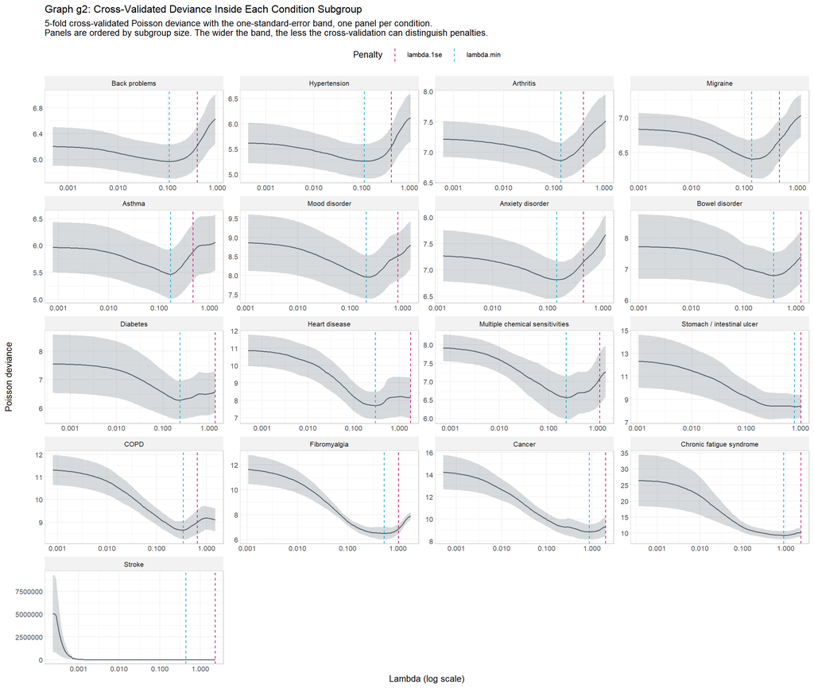

Panels are ordered by subgroup size, so the sequence of small multiples is also a sequence in statistical power. The quantity to read across them is the width of the one-standard-error band relative to the depth of the minimum. Where the band is wide and the curve shallow, cross-validation cannot distinguish penalties over a broad range, and `lambda.1se` will sit far to the right of `lambda.min` and discard nearly everything.

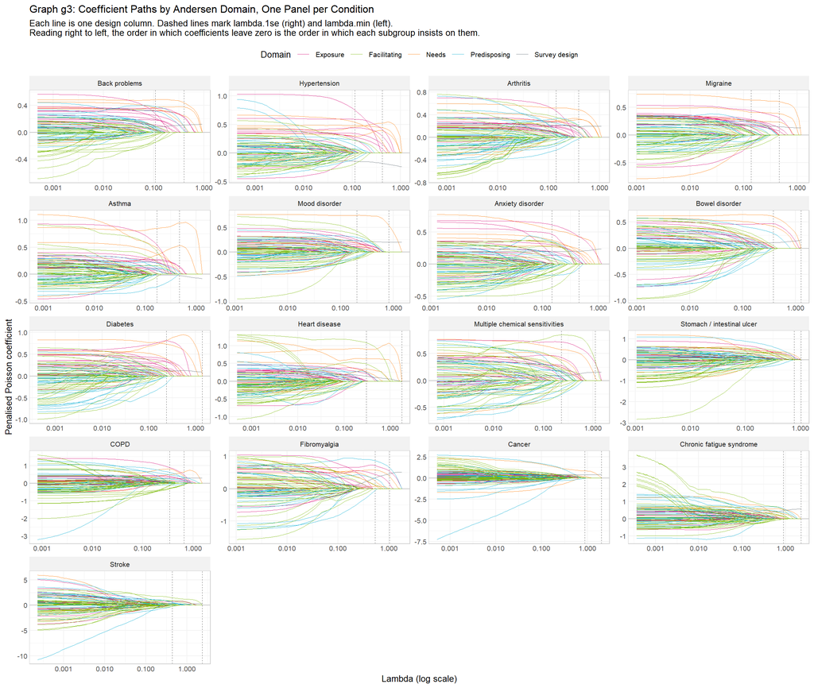

Reading each panel right to left, the order in which coefficients leave zero is the order in which that subgroup insists on them. Comparing panels shows whether the same domains lead in every condition or whether each disease has its own hierarchy.

**Review point 6**

Agree or disagree with the fitting choices, which are inherited unchanged from model-1: five folds, seed 42, survey weights passed to `cv.glmnet`, cycle exempt from the penalty. The one new consideration is that five folds of a subgroup are much thinner than five folds of the Section 5.5 sample, which is visible in the width of the bands in Graph g2.

## Step 7 — Selection Results

Table t5: What each subgroup retained under each penalty rule. The cycle indicator is exempt from the penalty (inherited decision 8), so a count of 1 variable means nothing but cycle survived. Compare the two ‘Vars kept’ columns: the difference between them is the evidence behind decision 25.

| Condition | n | n with >= 1 day | Columns offered | Cols kept (min) | Vars kept (min) | Cols kept (1SE) | Vars kept (1SE) |
| --- | --- | --- | --- | --- | --- | --- | --- |
| Back problems | 9,044 | 3,510 | 85 | 33 | 27 | 10 | 10 |
| Hypertension | 7,017 | 2,142 | 85 | 26 | 24 | 9 | 9 |
| Arthritis | 6,552 | 2,322 | 85 | 36 | 29 | 13 | 13 |
| Migraine | 5,162 | 2,330 | 85 | 36 | 30 | 7 | 7 |
| Asthma | 3,853 | 1,571 | 85 | 23 | 21 | 8 | 8 |
| Mood disorder | 3,296 | 1,674 | 85 | 29 | 22 | 2 | 2 |
| Anxiety disorder | 2,670 | 1,306 | 85 | 39 | 27 | 12 | 12 |
| Bowel disorder | 2,372 | 1,094 | 85 | 9 | 9 | 1 | 1 |
| Diabetes | 2,329 | 754 | 85 | 18 | 18 | 1 | 1 |
| Heart disease | 1,364 | 443 | 85 | 11 | 11 | 1 | 1 |
| Multiple chemical sensitivities | 1,279 | 579 | 85 | 30 | 23 | 4 | 4 |
| Stomach / intestinal ulcer | 1,123 | 468 | 85 | 7 | 7 | 1 | 1 |
| COPD | 932 | 393 | 85 | 30 | 24 | 16 | 15 |
| Fibromyalgia | 590 | 272 | 85 | 11 | 11 | 5 | 5 |
| Cancer | 559 | 248 | 85 | 6 | 6 | 1 | 1 |
| Chronic fatigue syndrome | 438 | 230 | 85 | 12 | 10 | 1 | 1 |
| Stroke | 187 | 79 | 85 | 15 | 12 | 1 | 1 |

Two comparisons carry the table. Reading across, the gap between the `min` and `1SE` columns is the evidence for decision 25 — whether the parsimonious rule has anything to say at this scale. Reading down, the relationship between subgroup size and the number of variables retained shows whether selection is tracking evidence or tracking sample size.

Table t51: Which variables each condition retained. ‘both’ means the variable survived at both penalties, ‘min’ only at lambda.min, ‘1SE’ only at lambda.1se, and blank means it was offered and eliminated. An empty cell for a variable that was never offered - because it went constant inside that subgroup - is indistinguishable here; Table t2 carries the drop counts.

| Domain | Variable | Back problems | Hypertension | Arthritis | Migraine | Asthma | Mood disorder | Anxiety disorder | Bowel disorder | Diabetes | Heart disease | Multiple chemical sensitivities | Stomach / intestinal ulcer | COPD | Fibromyalgia | Cancer | Chronic fatigue syndrome | Stroke |
| --- | --- | --- | --- | --- | --- | --- | --- | --- | --- | --- | --- | --- | --- | --- | --- | --- | --- | --- |
| Exposure | Anxiety disorder | min |  |  |  | min | min |  | min |  | min |  |  | min |  |  |  | min |
| Exposure | Arthritis | both | both |  | both | both |  |  |  |  |  |  |  |  |  |  |  |  |
| Exposure | Asthma | min |  | min |  |  |  |  |  |  |  |  |  |  |  |  |  |  |
| Exposure | Back problems |  | both | both | both | both |  | both |  | min |  | min |  | min |  |  |  |  |
| Exposure | Bowel disorder |  |  | min |  | min | min | both |  |  |  |  |  |  |  |  |  |  |
| Exposure | Cancer | min | min | min |  | min |  | min |  | min |  | min |  | both |  |  |  |  |
| Exposure | Chronic fatigue syndrome | min | min | both | min |  | min | both |  | min | min |  |  |  | both |  |  |  |
| Exposure | Diabetes | min | min | min | min |  |  |  |  |  |  | min |  |  | both |  |  |  |
| Exposure | Fibromyalgia |  |  |  | min |  |  |  |  | min |  | min |  |  |  |  |  |  |
| Exposure | Heart disease |  | min |  | min |  |  | min |  | min |  | min |  |  |  |  |  |  |
| Exposure | Hypertension | min |  | min | min |  | min |  |  |  |  |  |  |  |  | min |  |  |
| Exposure | Migraine | both | both | both |  | both | min | min |  | min | min | min | min | both |  |  |  |  |
| Exposure | Mood disorder | both | both | both | both | min |  | both | min |  |  | both |  | both |  |  | min |  |
| Exposure | Multiple chemical sensitivities | min |  |  | min |  | min |  |  | min |  |  |  | min |  |  |  |  |
| Exposure | Stomach / intestinal ulcer | min |  | min | min |  |  |  |  | min |  |  |  | both |  |  |  |  |
| Exposure | Stroke |  |  |  |  |  |  | min |  |  |  |  |  |  |  |  |  |  |
| Predisposing | Age group |  | min | both | min |  | min |  |  |  |  |  |  | both |  |  |  | min |
| Predisposing | Child aged 0-5 in household |  |  |  |  |  |  |  |  |  |  |  |  | min |  |  |  |  |
| Predisposing | Child aged 6-11 in household |  |  |  | min |  |  |  |  |  |  |  |  |  |  |  |  |  |
| Predisposing | Education | min |  | min | min |  |  | min |  |  | min | min |  | min |  | min |  |  |
| Predisposing | Home ownership |  | min | min |  | both | min |  | min |  |  | min |  |  |  |  |  |  |
| Predisposing | Household size |  | min | min |  |  |  | min |  |  |  | min |  | min |  |  |  |  |
| Predisposing | Immigration status | min |  | min | min | min |  | min |  |  |  |  | min |  |  |  |  | min |
| Predisposing | Living arrangements | both | min | both | min | min | min | both |  | min |  | min |  | both | min |  | min | min |
| Predisposing | Marital status | both | min | both | min | min | min | both |  |  |  | min |  | both | both |  | min | min |
| Predisposing | Sex | min |  |  |  | min |  | min |  |  |  |  |  | both |  |  |  |  |
| Predisposing | Visible minority |  |  |  |  |  | min |  |  | min |  | min |  |  | min |  |  | min |
| Facilitating | Alcohol consumption | min | min | min | min |  |  | min | min |  |  | min | min | both |  |  |  | min |
| Facilitating | BMI category |  | min | min |  | min |  |  | min |  |  |  | min |  | min |  |  | min |
| Facilitating | Employment type |  | min |  |  |  |  | min |  |  |  |  |  | both |  |  |  | min |
| Facilitating | Fruit / vegetable servings | min |  | min | min | min | min | min |  |  | min | min |  |  |  |  | min |  |
| Facilitating | Household income |  |  |  | min |  | min | min |  |  |  |  |  |  |  |  |  |  |
| Facilitating | Occupation category | min |  |  | min |  |  | min |  | min |  |  |  | both |  |  |  | min |
| Facilitating | Physical activity |  | min | min | min |  |  |  |  |  |  | min |  |  |  | min |  |  |
| Facilitating | Province | min |  | min | min | min | min | min |  | min |  | both |  | both |  |  | min | min |
| Facilitating | Smoking status |  |  | min |  |  | min |  | min |  |  | min |  | min |  |  |  |  |
| Facilitating | Work schedule | min | min |  | min |  | min | both |  |  |  |  |  |  |  |  |  |  |
| Facilitating | Work stress | min | min | both | min | min | min | min |  | min | min | min |  |  |  |  | min |  |
| Needs | Injured in past 12 months | both | both | both | min | both | min | both |  | min |  | min | min | min | min |  | min |  |
| Needs | Needs help: errands | both | both | both | both | both | min | both | min | min | min |  |  | min | min | min | min |  |
| Needs | Needs help: finances |  |  |  |  |  |  |  |  |  |  |  |  | both |  |  |  |  |
| Needs | Needs help: housework | both | both | both | both |  | both | both | min | min | min | both | min |  | both | min | min |  |
| Needs | Needs help: meals | both | both | both | both | both | min | both |  | min | min |  |  |  | min |  |  |  |
| Needs | Needs help: moving indoors |  |  |  |  | min |  |  |  |  | min | min |  | both |  |  |  |  |
| Needs | Needs help: personal care |  |  |  | min |  |  |  |  |  |  |  |  |  |  |  |  |  |
| Survey design | CCHS cycle | both | both | both | both | both | both | both | both | both | both | both | both | both | both | both | both | both |

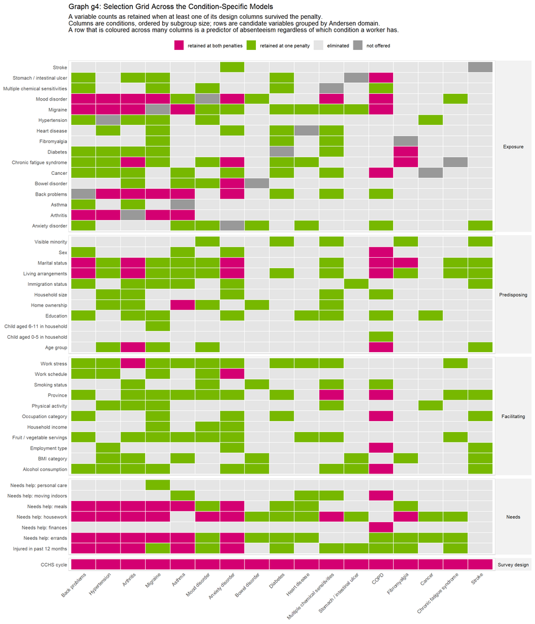

Graph g4 is this report’s central artifact, and it is read in two directions.

Reading **down a column** gives one condition’s whole verdict: the variables that predict absence among workers who have that disease. That is the Section 5.7 deliverable in visual form.

Reading **across a row** gives something Section 5.7 does not ask for but which falls out of asking it seventeen times. A variable coloured across many columns predicts absence more or less regardless of which chronic condition a worker carries; a variable coloured in one or two columns is specific to those diseases. The first kind belongs in a general model of absence, which is what model-1 estimates. The second kind is what a condition-specific analysis exists to find.

**Review point 7**

This is the report’s substantive output alongside Table 4. Two questions to settle:

1. Are the recurring rows in Graph g4 genuine cross-condition predictors, or are they variables that a large subgroup can afford to retain and a small one cannot? The subgroup-size ordering of the columns is there to make that check possible; a row that fills the left of the grid and empties toward the right is a power artifact, not a finding.
2. Should “retained” continue to mean “at least one design column survived”? Inherited decision 9 records the alternative. It matters more here than in model-1, because a factor with many levels retained on the strength of one thin cell contributes a term that Table t62 may then mark unstable.

## Step 8 — Stage Two, Negative Binomial Estimation

Each retained set is re-estimated without penalty under a negative binomial likelihood, inside its own subgroup. This step answers Section 5.7 and produces deliverable **Table 4**. Before the estimates, the instruments used to bracket their uncertainty.

**Fit and persist the condition-specific negative binomial models**

```r
nb_keys <- tidyr::expand_grid(
  condition = fitted_ok,
  spec_id = condition_specs$spec_id
) %>%
  mutate(key = paste0(condition, "__", spec_id))

spec_terms <- purrr::set_names(
  purrr::map2(nb_keys$condition, nb_keys$spec_id, function(this_condition, this_spec) {
    kept <- selection_long %>%
      filter(condition == this_condition, spec_id == this_spec) %>%
      retained_variables()
    union(condition_fits[[this_condition]]$forced,
          setdiff(kept, condition_fits[[this_condition]]$forced))
  }),
  nb_keys$key
)

nb_fits <- purrr::imap(spec_terms, function(term_vars, this_key) {
  this_condition <- sub("__.*$", "", this_key)
  fit_nb(condition_fits[[this_condition]]$subgroup, term_vars, outcome_var)
})

nb_nulls <- purrr::map(
  stats::setNames(fitted_ok, fitted_ok),
  ~ fit_nb(condition_fits[[.x]]$subgroup, character(0), outcome_var)
)

for (this_key in names(nb_fits)) {
  if (!is.null(nb_fits[[this_key]])) {
    saveRDS(nb_fits[[this_key]], paste0(fits_folder, "nb_", this_key, ".rds"))
  }
}
saveRDS(nb_nulls, paste0(fits_folder, "nb_nulls.rds"))

nb_coefficients <- purrr::imap_dfr(nb_fits, function(fit, this_key) {
  if (is.null(fit)) return(tibble::tibble())
  this_condition <- sub("__.*$", "", this_key)
  this_spec <- sub("^.*__", "", this_key)
  tidy_nb(fit, condition_fits[[this_condition]]$design$map,
          deff = condition_fits[[this_condition]]$kish_deff) %>%
    mutate(condition = this_condition, spec_id = this_spec)
}) %>%
  left_join(condition_specs %>% select(spec_id, model_label, role), by = "spec_id") %>%
  mutate(
    domain = variable_domains[variable],
    variable_label = variable_labels[variable],
    condition_label = variable_labels[condition],
    term = paste0(variable_label, ifelse(level == "", "", paste0(": ", level)))
  )

readr::write_csv(nb_coefficients, paste0(local_data, "nb-coefficients.csv"))
```

```
Output out5: Variance-estimation instruments for Section 5.7
```

```
Section 5.7 asks for 500 bootstrap replicate weights, the same instrument
```

```
Sections 5.3 and 5.5 ask for. They do not exist in the 2010 or 2014 PUMF
```

```
(inherited decision 10), and strata and PSU identifiers are suppressed, so
```

```
no fully design-based variance estimator can be built for any subgroup.
```

```
What follows are two LOWER bounds on how far the model-based intervals
```

```
understate uncertainty. Neither sees clustering.
```

```
Kish design effect, computed WITHIN each subgroup (decision 29):
```

```
                       Condition     n Kish deff Effective n SE multiplier
                   Back problems 9,044     3.837       2,357         1.959
                    Hypertension 7,017     4.218       1,664         2.054
                       Arthritis 6,552     4.007       1,635         2.002
                        Migraine 5,162     3.198       1,614         1.788
                          Asthma 3,853     3.488       1,105         1.867
                   Mood disorder 3,296     3.191       1,033         1.786
                Anxiety disorder 2,670     3.339         800         1.827
                  Bowel disorder 2,372     3.033         782         1.741
                        Diabetes 2,329     3.805         612         1.951
                   Heart disease 1,364     3.139         435         1.772
 Multiple chemical sensitivities 1,279     3.678         348         1.918
      Stomach / intestinal ulcer 1,123     3.693         304         1.922
                            COPD   932     4.394         212         2.096
                    Fibromyalgia   590     4.228         140         2.056
                          Cancer   559     3.179         176         1.783
        Chronic fatigue syndrome   438     2.675         164         1.636
                          Stroke   187     2.270          82         1.507
```

```
Huber-White sandwich SE multiplier, over every term in every fitted model:
```

```
  median: 1.321
```

```
  range:  0.000 to 3.434
```

```
  terms:  572
```

```
The spread is wider than model-1's because subgroup cells are thinner. A
```

```
multiplier below 1 is not a narrowing of the true interval; it is a thin
```

```
cell in which the sandwich estimator is itself unreliable. Table t62
```

```
reports all three interval variants side by side and marks terms whose
```

```
standard error exceeds 2 on the log scale (decision 27).
```

The design effect varies across subgroups, which is the reason it is computed within them rather than inherited from the pooled sample. A single number applied to all seventeen would widen some intervals too much and others not enough, and the direction of the error would be unknowable from the table.

The sandwich multipliers spread more widely than they do in model-1, and the low end of that spread should not be read as good news. A multiplier below 1 means the sandwich estimator has landed in a cell too thin to estimate its own variance reliably; it is a symptom of the same smallness that decision 27 flags, not a demonstration that the model-based interval was conservative.

Table t6 (deliverable Table 4): Adjusted prevalence rate ratios with 95% Wald intervals for every term retained inside every condition subgroup, under both penalty rules. An asterisk marks Wald p < 0.05; an exclamation mark flags a term whose standard error exceeds 2 on the log scale and whose interval is therefore uninformative (decision 27). A blank cell means the term was not retained under that penalty. These are NOT bootstrap intervals (inherited decision 10), and they ignore the selection step that produced the term list. Table t62 carries the log-scale coefficients, standard errors, exact p-values and two wider interval variants.

| Condition | n | Weighted N | Domain | Term | PR (95% CI), lambda.min | PR (95% CI), lambda.1SE |
| --- | --- | --- | --- | --- | --- | --- |
| Back problems | 9,044 | 2,404,140 | Exposure | Anxiety disorder: Yes | 1.18 (0.99-1.40) |  |
| Back problems | 9,044 | 2,404,140 | Exposure | Arthritis: Yes | 1.44 (1.29-1.61)* | 1.54 (1.38-1.72)* |
| Back problems | 9,044 | 2,404,140 | Exposure | Asthma: Yes | 1.16 (1.00-1.34) |  |
| Back problems | 9,044 | 2,404,140 | Exposure | Cancer: Yes | 2.13 (1.51-3.01)* |  |
| Back problems | 9,044 | 2,404,140 | Exposure | Chronic fatigue syndrome: Yes | 1.20 (0.86-1.66) |  |
| Back problems | 9,044 | 2,404,140 | Exposure | Diabetes: Yes | 1.57 (1.27-1.95)* |  |
| Back problems | 9,044 | 2,404,140 | Exposure | Hypertension: Yes | 1.30 (1.14-1.49)* |  |
| Back problems | 9,044 | 2,404,140 | Exposure | Migraine: Yes | 1.44 (1.28-1.63)* | 1.62 (1.44-1.83)* |
| Back problems | 9,044 | 2,404,140 | Exposure | Mood disorder: Yes | 1.51 (1.28-1.77)* | 1.76 (1.51-2.05)* |
| Back problems | 9,044 | 2,404,140 | Exposure | Multiple chemical sensitivities: Yes | 1.07 (0.86-1.35) |  |
| Back problems | 9,044 | 2,404,140 | Exposure | Stomach / intestinal ulcer: Yes | 1.24 (1.01-1.52)* |  |
| Back problems | 9,044 | 2,404,140 | Predisposing | Education: Post-secondary graduate | 1.11 (0.93-1.32) |  |
| Back problems | 9,044 | 2,404,140 | Predisposing | Education: Secondary graduate | 1.18 (0.97-1.43) |  |
| Back problems | 9,044 | 2,404,140 | Predisposing | Education: Some post-secondary | 1.26 (0.97-1.64) |  |
| Back problems | 9,044 | 2,404,140 | Predisposing | Immigration status: Long-term immigrant (10+ yrs in Canada) | 0.85 (0.74-0.98)* |  |
| Back problems | 9,044 | 2,404,140 | Predisposing | Immigration status: Recent immigrant (0-9 yrs in Canada) | 1.33 (1.02-1.72)* |  |
| Back problems | 9,044 | 2,404,140 | Predisposing | Living arrangements: Child in parent / sibling household | 1.31 (0.90-1.91) | 1.11 (0.76-1.62) |
| Back problems | 9,044 | 2,404,140 | Predisposing | Living arrangements: Child in two-parent / sibling household | 1.27 (0.96-1.68) | 1.13 (0.85-1.50) |
| Back problems | 9,044 | 2,404,140 | Predisposing | Living arrangements: Couple with children | 1.35 (0.98-1.86) | 1.26 (0.91-1.73) |
| Back problems | 9,044 | 2,404,140 | Predisposing | Living arrangements: Couple, no children | 1.36 (0.99-1.88) | 1.32 (0.95-1.83) |
| Back problems | 9,044 | 2,404,140 | Predisposing | Living arrangements: Other arrangement | 1.20 (0.89-1.61) | 1.10 (0.81-1.48) |
| Back problems | 9,044 | 2,404,140 | Predisposing | Living arrangements: Single parent with child | 1.39 (1.09-1.77)* | 1.41 (1.10-1.81)* |
| Back problems | 9,044 | 2,404,140 | Predisposing | Living arrangements: Unattached, living with others | 0.89 (0.69-1.15) | 0.93 (0.71-1.20) |
| Back problems | 9,044 | 2,404,140 | Predisposing | Marital status: Common-law | 0.87 (0.76-1.01) | 0.97 (0.84-1.11) |
| Back problems | 9,044 | 2,404,140 | Predisposing | Marital status: Single / Never married | 1.87 (1.38-2.54)* | 1.78 (1.31-2.42)* |
| Back problems | 9,044 | 2,404,140 | Predisposing | Marital status: Widowed / Separated / Divorced | 1.57 (1.14-2.18)* | 1.57 (1.13-2.17)* |
| Back problems | 9,044 | 2,404,140 | Predisposing | Sex: Female | 1.34 (1.20-1.49)* |  |
| Back problems | 9,044 | 2,404,140 | Facilitating | Alcohol consumption: Did not drink in past 12 months | 1.20 (1.04-1.39)* |  |
| Back problems | 9,044 | 2,404,140 | Facilitating | Alcohol consumption: Occasional drinker | 0.91 (0.80-1.04) |  |
| Back problems | 9,044 | 2,404,140 | Facilitating | Fruit / vegetable servings: 5 to 10 per day | 0.82 (0.74-0.91)* |  |

[output cut: 631 more lines]

Table t62 (deliverable Table 4, full ledger): Everything Section 5.7 asks to be reported - unweighted n, weighted N, log-scale coefficient, standard error, prevalence rate ratio, 95% interval and Wald p-value - for every term in every condition-specific model. The sandwich and Kish columns bracket the understatement caused by the absent bootstrap weights (inherited decisions 10 and 15); both are lower bounds. All intervals remain conditional on a selection step that used the same subgroup.

| Condition | n | Weighted N | Specification | Domain | Term | Beta (log) | SE | SE robust | PR | 95% CI (Wald) | 95% CI (sandwich) | 95% CI (Kish) | p (Wald) | p (robust) | Flag |
| --- | --- | --- | --- | --- | --- | --- | --- | --- | --- | --- | --- | --- | --- | --- | --- |
| Back problems | 9,044 | 2,404,140 | Parsimonious (1SE) | Exposure | Arthritis: Yes | 0.4316 | 0.0564 | 0.1011 | 1.540 | 1.378-1.720 | 1.263-1.877 | 1.240-1.912 | <0.0001 | <0.0001 |  |
| Back problems | 9,044 | 2,404,140 | Parsimonious (1SE) | Exposure | Migraine: Yes | 0.4825 | 0.0618 | 0.1417 | 1.620 | 1.435-1.829 | 1.227-2.139 | 1.278-2.054 | <0.0001 | 0.0007 |  |
| Back problems | 9,044 | 2,404,140 | Parsimonious (1SE) | Exposure | Mood disorder: Yes | 0.5652 | 0.0776 | 0.1238 | 1.760 | 1.512-2.049 | 1.381-2.243 | 1.307-2.370 | <0.0001 | <0.0001 |  |
| Back problems | 9,044 | 2,404,140 | Parsimonious (1SE) | Predisposing | Living arrangements: Child in parent / sibling household | 0.1029 | 0.1938 | 0.2259 | 1.108 | 0.758-1.621 | 0.712-1.726 | 0.527-2.333 | 0.5953 | 0.6486 |  |
| Back problems | 9,044 | 2,404,140 | Parsimonious (1SE) | Predisposing | Living arrangements: Child in two-parent / sibling household | 0.1229 | 0.1435 | 0.1855 | 1.131 | 0.853-1.498 | 0.786-1.626 | 0.652-1.962 | 0.3920 | 0.5077 |  |
| Back problems | 9,044 | 2,404,140 | Parsimonious (1SE) | Predisposing | Living arrangements: Couple with children | 0.2284 | 0.1645 | 0.2645 | 1.257 | 0.910-1.735 | 0.748-2.110 | 0.668-2.363 | 0.1649 | 0.3879 |  |
| Back problems | 9,044 | 2,404,140 | Parsimonious (1SE) | Predisposing | Living arrangements: Couple, no children | 0.2783 | 0.1656 | 0.2550 | 1.321 | 0.955-1.827 | 0.801-2.177 | 0.699-2.494 | 0.0929 | 0.2753 |  |
| Back problems | 9,044 | 2,404,140 | Parsimonious (1SE) | Predisposing | Living arrangements: Other arrangement | 0.0915 | 0.1521 | 0.2538 | 1.096 | 0.813-1.476 | 0.666-1.802 | 0.611-1.965 | 0.5476 | 0.7186 |  |
| Back problems | 9,044 | 2,404,140 | Parsimonious (1SE) | Predisposing | Living arrangements: Single parent with child | 0.3457 | 0.1264 | 0.1676 | 1.413 | 1.103-1.810 | 1.017-1.962 | 0.870-2.295 | 0.0062 | 0.0391 |  |
| Back problems | 9,044 | 2,404,140 | Parsimonious (1SE) | Predisposing | Living arrangements: Unattached, living with others | -0.0769 | 0.1321 | 0.1816 | 0.926 | 0.715-1.200 | 0.649-1.322 | 0.558-1.537 | 0.5602 | 0.6717 |  |
| Back problems | 9,044 | 2,404,140 | Parsimonious (1SE) | Predisposing | Marital status: Common-law | -0.0321 | 0.0708 | 0.1328 | 0.968 | 0.843-1.112 | 0.747-1.256 | 0.738-1.271 | 0.6501 | 0.8090 |  |
| Back problems | 9,044 | 2,404,140 | Parsimonious (1SE) | Predisposing | Marital status: Single / Never married | 0.5770 | 0.1564 | 0.2597 | 1.781 | 1.311-2.419 | 1.070-2.962 | 0.977-3.246 | 0.0002 | 0.0263 |  |
| Back problems | 9,044 | 2,404,140 | Parsimonious (1SE) | Predisposing | Marital status: Widowed / Separated / Divorced | 0.4488 | 0.1664 | 0.2548 | 1.566 | 1.131-2.170 | 0.951-2.581 | 0.827-2.967 | 0.0070 | 0.0782 |  |
| Back problems | 9,044 | 2,404,140 | Parsimonious (1SE) | Needs | Injured in past 12 months: Yes | 0.5304 | 0.0565 | 0.0882 | 1.700 | 1.521-1.898 | 1.430-2.020 | 1.368-2.111 | <0.0001 | <0.0001 |  |
| Back problems | 9,044 | 2,404,140 | Parsimonious (1SE) | Needs | Needs help: errands: Yes | 0.5813 | 0.1637 | 0.1622 | 1.788 | 1.298-2.465 | 1.301-2.457 | 0.954-3.352 | 0.0004 | 0.0003 |  |
| Back problems | 9,044 | 2,404,140 | Parsimonious (1SE) | Needs | Needs help: housework: Yes | 0.5159 | 0.1079 | 0.1507 | 1.675 | 1.356-2.070 | 1.247-2.251 | 1.107-2.535 | <0.0001 | 0.0006 |  |
| Back problems | 9,044 | 2,404,140 | Parsimonious (1SE) | Needs | Needs help: meals: Yes | 0.3775 | 0.2117 | 0.2334 | 1.459 | 0.963-2.209 | 0.923-2.305 | 0.647-3.288 | 0.0745 | 0.1058 |  |
| Back problems | 9,044 | 2,404,140 | Parsimonious (1SE) | Survey design | CCHS cycle: 2013-2014 | 0.0676 | 0.0478 | 0.0939 | 1.070 | 0.974-1.175 | 0.890-1.286 | 0.891-1.285 | 0.1570 | 0.4719 |  |
| Back problems | 9,044 | 2,404,140 | Permissive (min) | Exposure | Anxiety disorder: Yes | 0.1650 | 0.0889 | 0.1268 | 1.179 | 0.991-1.404 | 0.920-1.512 | 0.838-1.659 | 0.0633 | 0.1930 |  |
| Back problems | 9,044 | 2,404,140 | Permissive (min) | Exposure | Arthritis: Yes | 0.3659 | 0.0571 | 0.1000 | 1.442 | 1.289-1.613 | 1.185-1.754 | 1.158-1.795 | <0.0001 | 0.0003 |  |
| Back problems | 9,044 | 2,404,140 | Permissive (min) | Exposure | Asthma: Yes | 0.1451 | 0.0745 | 0.1166 | 1.156 | 0.999-1.338 | 0.920-1.453 | 0.869-1.539 | 0.0514 | 0.2133 |  |
| Back problems | 9,044 | 2,404,140 | Permissive (min) | Exposure | Cancer: Yes | 0.7557 | 0.1761 | 0.2710 | 2.129 | 1.508-3.007 | 1.252-3.621 | 1.083-4.187 | <0.0001 | 0.0053 |  |
| Back problems | 9,044 | 2,404,140 | Permissive (min) | Exposure | Chronic fatigue syndrome: Yes | 0.1810 | 0.1676 | 0.1766 | 1.198 | 0.863-1.665 | 0.848-1.694 | 0.630-2.281 | 0.2802 | 0.3054 |  |
| Back problems | 9,044 | 2,404,140 | Permissive (min) | Exposure | Diabetes: Yes | 0.4520 | 0.1102 | 0.1870 | 1.572 | 1.266-1.950 | 1.089-2.267 | 1.030-2.399 | <0.0001 | 0.0156 |  |
| Back problems | 9,044 | 2,404,140 | Permissive (min) | Exposure | Hypertension: Yes | 0.2656 | 0.0674 | 0.1166 | 1.304 | 1.143-1.488 | 1.038-1.639 | 1.007-1.689 | <0.0001 | 0.0227 |  |
| Back problems | 9,044 | 2,404,140 | Permissive (min) | Exposure | Migraine: Yes | 0.3670 | 0.0625 | 0.1280 | 1.443 | 1.277-1.631 | 1.123-1.855 | 1.136-1.835 | <0.0001 | 0.0041 |  |
| Back problems | 9,044 | 2,404,140 | Permissive (min) | Exposure | Mood disorder: Yes | 0.4105 | 0.0822 | 0.1326 | 1.508 | 1.283-1.771 | 1.162-1.955 | 1.100-2.067 | <0.0001 | 0.0020 |  |
| Back problems | 9,044 | 2,404,140 | Permissive (min) | Exposure | Multiple chemical sensitivities: Yes | 0.0720 | 0.1150 | 0.1781 | 1.075 | 0.858-1.346 | 0.758-1.523 | 0.691-1.671 | 0.5316 | 0.6861 |  |
| Back problems | 9,044 | 2,404,140 | Permissive (min) | Exposure | Stomach / intestinal ulcer: Yes | 0.2151 | 0.1055 | 0.1612 | 1.240 | 1.008-1.525 | 0.904-1.701 | 0.827-1.860 | 0.0416 | 0.1821 |  |
| Back problems | 9,044 | 2,404,140 | Permissive (min) | Predisposing | Education: Post-secondary graduate | 0.1001 | 0.0898 | 0.1617 | 1.105 | 0.927-1.318 | 0.805-1.517 | 0.783-1.560 | 0.2651 | 0.5360 |  |

[output cut: 780 more lines]

Table t62 is the compliance artifact: every quantity Section 5.7 names — unweighted $n$, weighted $N$, coefficient, prevalence rate ratio, interval and Wald $p$-value — for every term in every condition-specific model. Read the three interval columns together, as in model-1: where the Wald and Kish intervals agree about whether they contain 1, the conclusion survives the weighting problem; where they disagree, the term is unresolved rather than null or significant.

Read the `UNSTABLE` flag first, though. A term carrying it comes from a factor level held up by a handful of respondents, and its interval is uninformative regardless of what the three variants say about it.

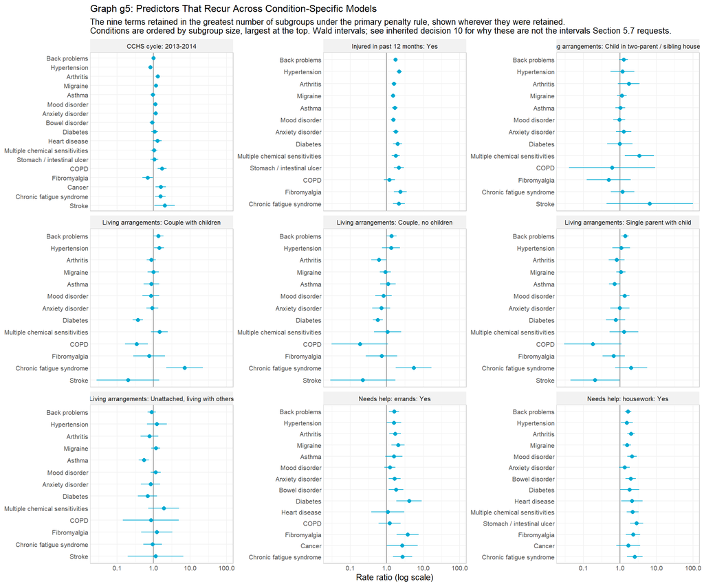

Graph g5 takes the terms retained in the greatest number of subgroups and shows their estimates wherever they were retained, with conditions ordered by subgroup size. A term whose rate ratios cluster tightly across many diseases is a general predictor of absence that happens to have been found seventeen times over. A term whose rate ratios scatter is either genuinely condition-dependent or under-determined, and the ordering by subgroup size usually tells which.

Table t61: Section 5.8 metrics computed IN SAMPLE, for every condition-specific model. RMSE and MAE are weighted (inherited decision 19). AIC and BIC come from a weighted pseudo-likelihood and rank models rather than measure them (inherited decision 18); across conditions they are not comparable at all, because each is computed on a different subgroup. Read them down a condition, never across. The held-out versions, which are the ones Section 5.8 actually asks for, are in Tables t63 and t64.

| Condition | Specification | n | Weighted N | Terms | AIC | BIC | McFadden R2 | Theta | RMSE | MAE | C-statistic | Comparable pairs | Converged |
| --- | --- | --- | --- | --- | --- | --- | --- | --- | --- | --- | --- | --- | --- |
| Back problems | Parsimonious (1SE) | 9,044 | 2,404,140 | 18 | 29,014 | 29,156 | 0.0202 | 0.2243 | 5.195 | 2.717 | 0.6227 | 60.1% | yes |
| Back problems | Permissive (min) | 9,044 | 2,404,140 | 55 | 28,846 | 29,251 | 0.0284 | 0.2377 | 5.152 | 2.659 | 0.6431 | 60.1% | yes |
| Hypertension | Parsimonious (1SE) | 7,017 | 1,654,969 | 9 | 18,632 | 18,707 | 0.0261 | 0.1665 | 4.685 | 2.241 | 0.6456 | 49.7% | yes |
| Hypertension | Permissive (min) | 7,017 | 1,654,969 | 43 | 18,473 | 18,775 | 0.0379 | 0.1808 | 4.984 | 2.272 | 0.6773 | 49.7% | yes |
| Arthritis | Parsimonious (1SE) | 6,552 | 1,445,511 | 25 | 20,760 | 20,944 | 0.0222 | 0.1919 | 5.700 | 2.961 | 0.6502 | 57.4% | yes |
| Arthritis | Permissive (min) | 6,552 | 1,445,511 | 63 | 20,645 | 21,079 | 0.0312 | 0.2046 | 6.118 | 2.985 | 0.6673 | 57.4% | yes |
| Migraine | Parsimonious (1SE) | 5,162 | 1,414,397 | 7 | 18,241 | 18,300 | 0.0167 | 0.2699 | 5.617 | 2.996 | 0.5868 | 66.5% | yes |
| Migraine | Permissive (min) | 5,162 | 1,414,397 | 63 | 17,988 | 18,414 | 0.0363 | 0.3090 | 5.535 | 2.877 | 0.6400 | 66.5% | yes |
| Asthma | Parsimonious (1SE) | 3,853 | 1,064,748 | 8 | 12,069 | 12,132 | 0.0230 | 0.2411 | 4.597 | 2.380 | 0.6098 | 60.0% | yes |
| Asthma | Permissive (min) | 3,853 | 1,064,748 | 45 | 11,945 | 12,239 | 0.0391 | 0.2701 | 5.074 | 2.428 | 0.6503 | 60.0% | yes |
| Mood disorder | Parsimonious (1SE) | 3,296 | 831,166 | 2 | 13,473 | 13,498 | 0.0068 | 0.2684 | 7.083 | 4.053 | 0.5453 | 71.7% | yes |
| Mood disorder | Permissive (min) | 3,296 | 831,166 | 49 | 13,256 | 13,567 | 0.0297 | 0.3156 | 6.850 | 3.844 | 0.6493 | 71.7% | yes |
| Anxiety disorder | Parsimonious (1SE) | 2,670 | 707,707 | 20 | 9,735 | 9,864 | 0.0290 | 0.2907 | 5.986 | 3.226 | 0.6282 | 67.7% | yes |
| Anxiety disorder | Permissive (min) | 2,670 | 707,707 | 61 | 9,661 | 10,026 | 0.0444 | 0.3224 | 6.056 | 3.183 | 0.6705 | 67.7% | yes |
| Bowel disorder | Parsimonious (1SE) | 2,372 | 571,139 | 1 | 8,947 | 8,964 | 0.0003 | 0.2498 | 5.956 | 3.425 | 0.4991 | 68.4% | yes |
| Bowel disorder | Permissive (min) | 2,372 | 571,139 | 14 | 8,767 | 8,859 | 0.0233 | 0.2936 | 5.536 | 3.113 | 0.6195 | 68.4% | yes |
| Diabetes | Parsimonious (1SE) | 2,329 | 559,717 | 1 | 6,573 | 6,590 | 0.0001 | 0.1431 | 5.277 | 2.623 | 0.4879 | 51.6% | yes |
| Diabetes | Permissive (min) | 2,329 | 559,717 | 39 | 6,355 | 6,591 | 0.0449 | 0.1964 | 7.698 | 2.611 | 0.6653 | 51.6% | yes |
| Heart disease | Parsimonious (1SE) | 1,364 | 298,377 | 1 | 4,306 | 4,322 | 0.0000 | 0.1500 | 5.991 | 3.374 | 0.5280 | 55.8% | yes |
| Heart disease | Permissive (min) | 1,364 | 298,377 | 17 | 4,236 | 4,335 | 0.0239 | 0.1785 | 5.657 | 2.942 | 0.6008 | 55.8% | yes |
| Multiple chemical sensitivities | Parsimonious (1SE) | 1,279 | 301,153 | 13 | 4,488 | 4,566 | 0.0261 | 0.2853 | 5.633 | 2.918 | 0.6046 | 66.5% | yes |
| Multiple chemical sensitivities | Permissive (min) | 1,279 | 301,153 | 53 | 4,330 | 4,609 | 0.0776 | 0.4048 | 6.196 | 2.895 | 0.6966 | 66.5% | yes |
| Stomach / intestinal ulcer | Parsimonious (1SE) | 1,123 | 320,726 | 1 | 4,133 | 4,148 | 0.0000 | 0.2028 | 6.320 | 3.794 | 0.4990 | 64.8% | yes |
| Stomach / intestinal ulcer | Permissive (min) | 1,123 | 320,726 | 11 | 4,030 | 4,095 | 0.0298 | 0.2507 | 6.028 | 3.385 | 0.6702 | 64.8% | yes |
| COPD | Parsimonious (1SE) | 932 | 194,850 | 36 | 3,428 | 3,612 | 0.0616 | 0.2896 | 9.468 | 4.320 | 0.7275 | 64.6% | yes |
| COPD | Permissive (min) | 932 | 194,850 | 52 | 3,431 | 3,687 | 0.0692 | 0.3082 | 8.572 | 4.218 | 0.7436 | 64.6% | NO |
| Fibromyalgia | Parsimonious (1SE) | 590 | 152,033 | 7 | 2,105 | 2,144 | 0.0412 | 0.3008 | 5.254 | 2.804 | 0.6687 | 66.4% | yes |
| Fibromyalgia | Permissive (min) | 590 | 152,033 | 21 | 2,061 | 2,162 | 0.0742 | 0.3765 | 5.976 | 2.973 | 0.7140 | 66.4% | yes |
| Cancer | Parsimonious (1SE) | 559 | 122,184 | 1 | 2,325 | 2,338 | 0.0022 | 0.2502 | 7.155 | 4.599 | 0.4828 | 71.9% | yes |
| Cancer | Permissive (min) | 559 | 122,184 | 9 | 2,294 | 2,342 | 0.0222 | 0.2877 | 6.754 | 4.102 | 0.5594 | 71.9% | yes |
| Chronic fatigue syndrome | Parsimonious (1SE) | 438 | 103,679 | 1 | 2,042 | 2,055 | 0.0046 | 0.2904 | 8.287 | 5.498 | 0.5284 | 77.2% | yes |
| Chronic fatigue syndrome | Permissive (min) | 438 | 103,679 | 31 | 1,963 | 2,098 | 0.0727 | 0.4720 | 8.100 | 4.321 | 0.7422 | 77.2% | yes |
| Stroke | Parsimonious (1SE) | 187 | 35,814 | 1 | 664 | 674 | 0.0008 | 0.1799 | 6.153 | 3.730 | 0.4914 | 61.9% | yes |
| Stroke | Permissive (min) | 187 | 35,814 | 37 | 659 | 785 | 0.1184 | 0.4255 | 10.994 | 3.886 | 0.8016 | 61.9% | NO |

```
Output out3: Convergence, dispersion, and the empty-selection count
```

```
Section 5.7 asks for conditions where the model fails to converge to be
```

```
flagged explicitly. The count:
```

[output not shown]

```
Models that failed to converge:

 Condition    Specification   n
      COPD Permissive (min) 932
    Stroke Permissive (min) 187
```

```
Selections that retained nothing beyond the forced cycle indicator:
```

```
                  Condition      Specification     n Variables retained
             Bowel disorder Parsimonious (1SE) 2,372                  1
                     Cancer Parsimonious (1SE)   559                  1
                   Diabetes Parsimonious (1SE) 2,329                  1
   Chronic fatigue syndrome Parsimonious (1SE)   438                  1
              Heart disease Parsimonious (1SE) 1,364                  1
                     Stroke Parsimonious (1SE)   187                  1
 Stomach / intestinal ulcer Parsimonious (1SE) 1,123                  1
```

```
Dispersion across subgroups (theta; smaller means more overdispersed):
```

```
                       Condition     n  Theta
                   Back problems 9,044 0.2377
                    Hypertension 7,017 0.1808
                       Arthritis 6,552 0.2046
                        Migraine 5,162 0.3090
                          Asthma 3,853 0.2701
                   Mood disorder 3,296 0.3156
                Anxiety disorder 2,670 0.3224
                  Bowel disorder 2,372 0.2936
                        Diabetes 2,329 0.1964
                   Heart disease 1,364 0.1785
 Multiple chemical sensitivities 1,279 0.4048
      Stomach / intestinal ulcer 1,123 0.2507
                            COPD   932 0.3082
                    Fibromyalgia   590 0.3765
                          Cancer   559 0.2877
        Chronic fatigue syndrome   438 0.4720
                          Stroke   187 0.4255
```

One warning about Table t61 that does not apply to model-1’s version of it: **these rows are not comparable across conditions.** Each is computed on a different subgroup, of a different size, with a different outcome distribution. AIC and BIC in particular are computed from a weighted pseudo-likelihood on different data, so a smaller AIC in one row says nothing whatever about the row above it. Read the table down a condition — comparing the two specifications within a disease — and never across.

Output out3 answers Section 5.7’s explicit request that non-convergence be reported. It also counts the empty selections, which are not failures but are results a reader needs to see stated rather than inferred from a blank row in Table 4.

**Review point 8**

Agree or disagree that Tables t6 and t62 are fit to serve as the study’s Table 4. The specific questions to settle:

1. Should conditions flagged small in Table t11 be published at all, or reported as attempted-and-withheld? Section 5.7 asks for a flag, which is what is implemented; a stricter reading would suppress them.
2. Is the `UNSTABLE` flag at a standard error of 2 on the log scale the right threshold, and should flagged terms be shown or withheld?
3. Should the deliverable table carry both penalty rules, or should one be chosen and the other relegated to an appendix?

## Step 9 — Section 5.8, Held-Out Performance

Section 5.8 asks for AIC, BIC, McFadden’s pseudo-$R^2$, a C-statistic, and RMSE and MAE “computed on the withheld test fold,” averaged over five folds, for every condition-specific model. Table t61 gave the in-sample versions. This step supplies the rest.

It also declines an invitation. Section 5.8 offers leave-one-out as an option for small subgroups, at the analyst’s discretion. It is declined for a technical reason rather than a convenience one: Harrell’s C is computed over *pairs* of held-out respondents, and a leave-one-out fold contains one respondent. The C-statistic Section 5.8 asks for in the same paragraph would be undefined, and the between-fold spread that makes a cross-validated number readable would not exist. Five folds also keep model-2 on the same footing as model-1’s Tables t63 and t64. Decision 28.

**Five-fold cross-validation of every condition and specification, both variants**

```r
if (!force_refit_cv && file.exists(cv_cache_path)) {
  cv_performance <- readRDS(cv_cache_path)
  cat("Loaded cached cross-validation results from ", cv_cache_path, "\n", sep = "")
} else {
  cat("Refitting the Section 5.8 cross-validation. This is the slow block.\n")
  cv_start_time <- Sys.time()

  cv_performance <- purrr::map_dfr(fitted_ok, function(this_condition) {
    cf <- condition_fits[[this_condition]]
    sub <- cf$subgroup
    fold_id <- assign_folds(nrow(sub), perf_folds, perf_seed)
    cat("  ", this_condition, " (n = ", nrow(sub), ")\n", sep = "")

    purrr::map_dfr(seq_len(perf_folds), function(this_fold) {
      test_rows <- which(fold_id == this_fold)
      train_rows <- which(fold_id != this_fold)

      # Variant A - term set fixed at what the full subgroup selected.
      fixed <- purrr::pmap_dfr(
        condition_specs %>% select(spec_id),
        function(spec_id) {
          term_vars <- spec_terms[[paste0(this_condition, "__", spec_id)]]
          evaluate_fold(sub, train_rows, test_rows, term_vars, outcome_var) %>%
            mutate(condition = this_condition, spec_id = spec_id,
                   fold = this_fold, variant = "fixed term set")
        }
      )

      # Variant B - the whole two-stage procedure re-run inside the training
      # fold, so no held-out respondent contributed to selection.
      train_frame <- droplevels(sub[train_rows, , drop = FALSE])
      fold_offered <- subgroup_candidates(train_frame, this_condition,
                                          vars_excluding_perceived)
      fold_forced <- forced_vars[
        purrr::map_lgl(forced_vars, ~ is_informative(train_frame[[.x]]))
      ]
      fold_design <- if (length(fold_offered) > 0) {
        build_design(train_frame, c(fold_forced, fold_offered))
      } else {
        NULL
      }
      fold_lasso <- if (!is.null(fold_design)) {
        tryCatch(
          fit_lasso(fold_design, train_frame[[outcome_var]],
                    train_frame$weight_scaled, lasso_seed),
          error = function(e) NULL
        )
      } else {
        NULL
      }

      reselected <- purrr::pmap_dfr(
        condition_specs %>% select(spec_id, lambda_rule),
        function(spec_id, lambda_rule) {
          term_vars <- if (is.null(fold_lasso)) {
            fold_forced
          } else {
            kept <- coefficients_at(fold_lasso, fold_design, lambda_rule) %>%
              retained_variables()
            union(fold_forced, setdiff(kept, fold_forced))
          }
          evaluate_fold(sub, train_rows, test_rows, term_vars, outcome_var) %>%
            mutate(condition = this_condition, spec_id = spec_id,
                   fold = this_fold, variant = "selection re-run",
                   n_vars_selected = length(term_vars))
        }
      )

      bind_rows(fixed, reselected)
    })
  }) %>%
    left_join(condition_specs %>% select(spec_id, model_label, role), by = "spec_id") %>%
    mutate(condition_label = variable_labels[condition])

  attr(cv_performance, "elapsed_minutes") <-
    as.numeric(difftime(Sys.time(), cv_start_time, units = "mins"))
  saveRDS(cv_performance, cv_cache_path)
}

readr::write_csv(cv_performance, paste0(local_data, "cv-performance-folds.csv"))

cv_summary <- cv_performance %>%
  group_by(variant, condition, condition_label, spec_id, model_label) %>%
  summarise(
    folds_converged = sum(converged),
    n_terms_mean = mean(n_terms, na.rm = TRUE),
    n_terms_range = if (all(is.na(n_terms))) {
      "n/a"
    } else {
      paste0(min(n_terms, na.rm = TRUE), "-", max(n_terms, na.rm = TRUE))
    },
    rmse_mean = mean(rmse, na.rm = TRUE), rmse_sd = stats::sd(rmse, na.rm = TRUE),
    mae_mean = mean(mae, na.rm = TRUE), mae_sd = stats::sd(mae, na.rm = TRUE),
    mcfadden_mean = mean(mcfadden_r2, na.rm = TRUE),
    mcfadden_sd = stats::sd(mcfadden_r2, na.rm = TRUE),
    c_mean = mean(c_statistic, na.rm = TRUE), c_sd = stats::sd(c_statistic, na.rm = TRUE),
    comparable_share = mean(comparable_share, na.rm = TRUE),
    unscorable = sum(n_unscorable, na.rm = TRUE),
    .groups = "drop"
  ) %>%
  left_join(condition_inventory %>% select(condition, n), by = "condition") %>%
  arrange(variant, desc(n), spec_id)

readr::write_csv(cv_summary, paste0(local_data, "cv-performance-summary.csv"))
```

Table t63: Section 5.8 five-fold cross-validated performance, term set held FIXED across folds. Each cell is the mean over five folds of the condition’s own subgroup, with the between-fold standard deviation in parentheses. Metrics are computed on the withheld fold only, weighted (inherited decision 19). These numbers are optimistic: the LASSO that chose the term set saw every fold (inherited decision 16). Table t64 removes that advantage. Leave-one-out was declined - see decision 28.

| Condition | Specification | n | Terms | CV RMSE | CV MAE | CV McFadden R2 | CV C-statistic | Comparable pairs | Folds converged |
| --- | --- | --- | --- | --- | --- | --- | --- | --- | --- |
| Back problems | Parsimonious (1SE) | 9,044 | 18 | 5.267 (0.465) | 2.759 (0.175) | 0.0174 (0.0053) | 0.6147 (0.0439) | 60.2% | 5 / 5 |
| Back problems | Permissive (min) | 9,044 | 55 | 5.282 (0.495) | 2.750 (0.174) | 0.0155 (0.0076) | 0.6181 (0.0379) | 60.2% | 5 / 5 |
| Hypertension | Parsimonious (1SE) | 7,017 | 9 | 4.697 (0.616) | 2.254 (0.225) | 0.0250 (0.0056) | 0.6427 (0.0345) | 49.7% | 5 / 5 |
| Hypertension | Permissive (min) | 7,017 | 43 | 5.141 (0.686) | 2.372 (0.252) | 0.0176 (0.0123) | 0.6445 (0.0463) | 49.7% | 5 / 5 |
| Arthritis | Parsimonious (1SE) | 6,552 | 25 | 5.874 (0.580) | 3.057 (0.211) | 0.0129 (0.0101) | 0.6310 (0.0251) | 57.3% | 5 / 5 |
| Arthritis | Permissive (min) | 6,552 | 63 | 6.432 (0.756) | 3.165 (0.264) | 0.0053 (0.0073) | 0.6285 (0.0101) | 57.3% | 5 / 5 |
| Migraine | Parsimonious (1SE) | 5,162 | 7 | 5.685 (0.273) | 3.030 (0.134) | 0.0127 (0.0088) | 0.5826 (0.0062) | 66.5% | 5 / 5 |
| Migraine | Permissive (min) | 5,162 | 63 | 6.000 (0.176) | 3.108 (0.114) | 0.0041 (0.0243) | 0.6077 (0.0159) | 66.5% | 5 / 5 |
| Asthma | Parsimonious (1SE) | 3,853 | 8 | 4.622 (0.838) | 2.411 (0.290) | 0.0188 (0.0121) | 0.6063 (0.0111) | 59.8% | 5 / 5 |
| Asthma | Permissive (min) | 3,853 | 45 | 5.411 (0.696) | 2.563 (0.245) | 0.0067 (0.0119) | 0.6148 (0.0184) | 59.8% | 5 / 5 |
| Mood disorder | Parsimonious (1SE) | 3,296 | 2 | 7.045 (1.042) | 4.069 (0.369) | 0.0062 (0.0041) | 0.5472 (0.0262) | 71.9% | 5 / 5 |
| Mood disorder | Permissive (min) | 3,296 | 49 | 7.105 (0.876) | 4.023 (0.435) | 0.0119 (0.0035) | 0.6153 (0.0088) | 71.9% | 5 / 5 |
| Anxiety disorder | Parsimonious (1SE) | 2,670 | 20 | 6.133 (0.634) | 3.348 (0.276) | 0.0188 (0.0134) | 0.6106 (0.0503) | 67.7% | 5 / 5 |
| Anxiety disorder | Permissive (min) | 2,670 | 61 | 6.411 (0.625) | 3.416 (0.266) | 0.0145 (0.0154) | 0.6313 (0.0390) | 67.7% | 5 / 5 |
| Bowel disorder | Parsimonious (1SE) | 2,372 | 1 | 5.864 (1.206) | 3.429 (0.511) | 0.0001 (0.0007) | 0.5000 (0.0411) | 68.5% | 5 / 5 |
| Bowel disorder | Permissive (min) | 2,372 | 14 | 5.640 (0.935) | 3.209 (0.454) | 0.0115 (0.0138) | 0.5941 (0.0211) | 68.5% | 5 / 5 |
| Diabetes | Parsimonious (1SE) | 2,329 | 1 | 5.241 (1.037) | 2.651 (0.346) | -0.0004 (0.0008) | 0.4904 (0.0283) | 51.7% | 5 / 5 |
| Diabetes | Permissive (min) | 2,329 | 39 | 8.646 (1.829) | 2.885 (0.259) | 0.0077 (0.0289) | 0.6188 (0.0392) | 51.7% | 4 / 5 |
| Heart disease | Parsimonious (1SE) | 1,364 | 1 | 5.942 (1.430) | 3.425 (0.591) | -0.0054 (0.0065) | 0.4345 (0.0354) | 55.9% | 5 / 5 |
| Heart disease | Permissive (min) | 1,364 | 17 | 6.230 (1.371) | 3.311 (0.519) | 0.0029 (0.0245) | 0.5748 (0.0510) | 55.9% | 5 / 5 |
| Multiple chemical sensitivities | Parsimonious (1SE) | 1,279 | 13 | 5.821 (1.174) | 3.049 (0.468) | 0.0127 (0.0322) | 0.5897 (0.0308) | 65.5% | 5 / 5 |
| Multiple chemical sensitivities | Permissive (min) | 1,279 | 53 | 8.003 (1.488) | 3.515 (0.396) | -0.0197 (0.0625) | 0.6178 (0.0615) | 65.5% | 1 / 5 |
| Stomach / intestinal ulcer | Parsimonious (1SE) | 1,123 | 1 | 6.210 (1.313) | 3.799 (0.576) | -0.0025 (0.0031) | 0.4513 (0.0212) | 64.6% | 5 / 5 |
| Stomach / intestinal ulcer | Permissive (min) | 1,123 | 11 | 6.518 (1.041) | 3.697 (0.322) | -0.0373 (0.0888) | 0.6137 (0.0513) | 64.6% | 5 / 5 |
| COPD | Parsimonious (1SE) | 932 | 36 | 10.028 (3.795) | 5.014 (1.050) | -0.0549 (0.1041) | 0.6705 (0.0576) | 65.4% | 4 / 5 |
| COPD | Permissive (min) | 932 | 52 | 10.919 (1.680) | 5.506 (0.509) | -0.0861 (0.0978) | 0.6450 (0.0572) | 65.4% | 0 / 5 |
| Fibromyalgia | Parsimonious (1SE) | 590 | 7 | 5.883 (0.955) | 3.189 (0.480) | 0.0191 (0.0250) | 0.6174 (0.0837) | 66.5% | 5 / 5 |
| Fibromyalgia | Permissive (min) | 590 | 21 | 7.226 (2.538) | 3.574 (1.015) | 0.0129 (0.0373) | 0.6415 (0.0515) | 66.5% | 5 / 5 |
| Cancer | Parsimonious (1SE) | 559 | 1 | 7.252 (1.402) | 4.732 (0.613) | -0.0003 (0.0078) | 0.4828 (0.0810) | 72.5% | 5 / 5 |
| Cancer | Permissive (min) | 559 | 9 | 6.982 (1.220) | 4.323 (0.739) | 0.0066 (0.0135) | 0.5098 (0.0632) | 72.5% | 5 / 5 |
| Chronic fatigue syndrome | Parsimonious (1SE) | 438 | 1 | 7.930 (2.537) | 5.504 (1.057) | 0.0028 (0.0083) | 0.5348 (0.0705) | 77.9% | 5 / 5 |
| Chronic fatigue syndrome | Permissive (min) | 438 | 31 | 10.583 (3.651) | 5.553 (1.128) | -0.1431 (0.2628) | 0.6573 (0.0722) | 77.9% | 4 / 5 |
| Stroke | Parsimonious (1SE) | 187 | 1 | 6.112 (2.887) | 3.965 (1.473) | -0.0002 (0.0029) | 0.5015 (0.1009) | 63.0% | 5 / 5 |
| Stroke | Permissive (min) | 187 | 36 | 51.239 (43.426) | 16.331 (17.316) | -2.0553 (2.7963) | 0.6054 (0.1525) | 61.0% | 0 / 5 |

Table t63 is the literal answer to Section 5.8: the term set is what the full subgroup’s LASSO chose, and the negative binomial is refitted five times with a fifth of the subgroup withheld each time. It is also, for that reason, optimistic — the penalty that produced the term list saw every respondent it is now being scored on.

Table t64: The same five folds, with the entire two-stage procedure re-run inside each training fold so that no held-out respondent contributed to selection. The term range is the artifact to read first: it says how far a subgroup’s selected set moves when a fifth of it is withheld. In subgroups this size that range is the honest description of what Section 5.7 can and cannot establish.

| Condition | Specification | n | Terms (mean) | Terms (range) | CV RMSE | CV McFadden R2 | CV C-statistic | Folds converged |
| --- | --- | --- | --- | --- | --- | --- | --- | --- |
| Back problems | Parsimonious (1SE) | 9,044 | 16 | 10-22 | 5.236 (0.489) | 0.0142 (0.0050) | 0.6017 (0.0419) | 5 / 5 |
| Back problems | Permissive (min) | 9,044 | 52 | 41-56 | 5.351 (0.498) | 0.0109 (0.0069) | 0.6093 (0.0355) | 5 / 5 |
| Hypertension | Parsimonious (1SE) | 7,017 | 10 | 6-17 | 4.836 (0.743) | 0.0181 (0.0107) | 0.6129 (0.0474) | 5 / 5 |
| Hypertension | Permissive (min) | 7,017 | 45 | 24-70 | 6.204 (1.689) | 0.0112 (0.0130) | 0.6294 (0.0481) | 5 / 5 |
| Arthritis | Parsimonious (1SE) | 6,552 | 17 | 1-36 | 6.003 (0.659) | 0.0005 (0.0052) | 0.5784 (0.0478) | 5 / 5 |
| Arthritis | Permissive (min) | 6,552 | 55 | 39-68 | 6.315 (0.650) | 0.0054 (0.0072) | 0.6296 (0.0153) | 5 / 5 |
| Migraine | Parsimonious (1SE) | 5,162 | 2 | 1-5 | 5.758 (0.495) | 0.0006 (0.0036) | 0.5237 (0.0230) | 5 / 5 |
| Migraine | Permissive (min) | 5,162 | 59 | 52-63 | 6.168 (0.234) | -0.0031 (0.0233) | 0.6025 (0.0106) | 5 / 5 |
| Asthma | Parsimonious (1SE) | 3,853 | 15 | 1-35 | 5.066 (1.005) | 0.0082 (0.0091) | 0.5538 (0.0505) | 5 / 5 |
| Asthma | Permissive (min) | 3,853 | 64 | 57-76 | 7.592 (2.558) | -0.0267 (0.0265) | 0.5973 (0.0184) | 4 / 5 |
| Mood disorder | Parsimonious (1SE) | 3,296 | 2 | 1-2 | 7.114 (1.000) | 0.0036 (0.0048) | 0.5320 (0.0325) | 5 / 5 |
| Mood disorder | Permissive (min) | 3,296 | 41 | 9-61 | 7.220 (0.872) | 0.0049 (0.0108) | 0.6072 (0.0213) | 5 / 5 |
| Anxiety disorder | Parsimonious (1SE) | 2,670 | 20 | 3-33 | 6.343 (0.620) | 0.0071 (0.0170) | 0.5718 (0.0574) | 5 / 5 |
| Anxiety disorder | Permissive (min) | 2,670 | 58 | 55-63 | 6.568 (0.886) | 0.0062 (0.0179) | 0.6206 (0.0556) | 5 / 5 |
| Bowel disorder | Parsimonious (1SE) | 2,372 | 3 | 1-5 | 5.802 (0.892) | 0.0066 (0.0069) | 0.5409 (0.0569) | 5 / 5 |
| Bowel disorder | Permissive (min) | 2,372 | 24 | 8-46 | 5.873 (1.071) | -0.0053 (0.0403) | 0.5856 (0.0245) | 5 / 5 |
| Diabetes | Parsimonious (1SE) | 2,329 | 2 | 1-3 | 5.247 (1.047) | 0.0019 (0.0047) | 0.4979 (0.0320) | 5 / 5 |
| Diabetes | Permissive (min) | 2,329 | 27 | 6-43 | 7.333 (1.503) | 0.0015 (0.0282) | 0.6061 (0.0347) | 4 / 5 |
| Heart disease | Parsimonious (1SE) | 1,364 | 1 | 1-1 | 5.942 (1.430) | -0.0054 (0.0065) | 0.4345 (0.0354) | 5 / 5 |
| Heart disease | Permissive (min) | 1,364 | 14 | 1-21 | 6.392 (1.317) | -0.0115 (0.0198) | 0.5216 (0.0757) | 5 / 5 |
| Multiple chemical sensitivities | Parsimonious (1SE) | 1,279 | 3 | 1-12 | 6.049 (1.406) | -0.0080 (0.0158) | 0.5072 (0.0342) | 5 / 5 |
| Multiple chemical sensitivities | Permissive (min) | 1,279 | 49 | 33-63 | 7.920 (2.787) | -0.0406 (0.0683) | 0.6149 (0.0451) | 2 / 5 |
| Stomach / intestinal ulcer | Parsimonious (1SE) | 1,123 | 2 | 1-7 | 6.277 (1.421) | -0.0298 (0.0641) | 0.4602 (0.0315) | 5 / 5 |
| Stomach / intestinal ulcer | Permissive (min) | 1,123 | 27 | 1-52 | 8.196 (2.638) | -0.2998 (0.6142) | 0.5532 (0.1020) | 3 / 5 |
| COPD | Parsimonious (1SE) | 932 | 2 | 1-6 | 6.985 (0.489) | -0.0076 (0.0175) | 0.5146 (0.0287) | 5 / 5 |
| COPD | Permissive (min) | 932 | 40 | 14-51 | 11.387 (4.931) | -0.0677 (0.1013) | 0.6273 (0.0683) | 1 / 5 |
| Fibromyalgia | Parsimonious (1SE) | 590 | 7 | 1-13 | 6.494 (1.198) | -0.0162 (0.0226) | 0.4820 (0.0782) | 5 / 5 |
| Fibromyalgia | Permissive (min) | 590 | 29 | 11-41 | 8.931 (2.703) | -0.0711 (0.0880) | 0.6162 (0.0200) | 3 / 5 |
| Cancer | Parsimonious (1SE) | 559 | 1 | 1-1 | 7.252 (1.402) | -0.0003 (0.0078) | 0.4828 (0.0810) | 5 / 5 |
| Cancer | Permissive (min) | 559 | 10 | 2-28 | 7.502 (1.735) | -0.0189 (0.0277) | 0.4847 (0.0740) | 5 / 5 |
| Chronic fatigue syndrome | Parsimonious (1SE) | 438 | 1 | 1-1 | 7.930 (2.537) | 0.0028 (0.0083) | 0.5348 (0.0705) | 5 / 5 |
| Chronic fatigue syndrome | Permissive (min) | 438 | 47 | 35-63 | 17.230 (11.698) | -0.3641 (0.3132) | 0.5564 (0.0852) | 2 / 5 |
| Stroke | Parsimonious (1SE) | 187 | 1 | 1-1 | 6.112 (2.887) | -0.0002 (0.0029) | 0.5015 (0.1009) | 5 / 5 |
| Stroke | Permissive (min) | 187 | 26 | 1-51 | 14.470 (8.616) | -4.2106 (5.8696) | 0.4960 (0.1289) | 2 / 5 |

Table t64 removes that advantage by re-running the whole two-stage procedure inside each training fold. The term-count range is the column to read first. Model 1 found the selected set unstable even at forty-nine thousand respondents, ranging from eight to thirty-eight terms across folds. At subgroup scale the same measurement is the honest description of what a condition-specific selection can and cannot establish.

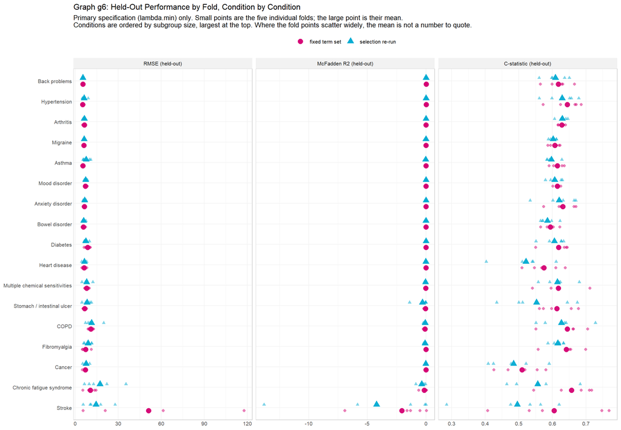

Graph g6 shows the five folds individually rather than only their mean, for the primary specification. Where the fold points for a condition scatter across the panel, the mean printed in Table t63 is not a number to quote, and the spread — not the mean — is the result.

```
Output out6: Reading the C-statistic, and the size of the selection optimism
```

```
Share of respondents at zero days, by subgroup:
```

```
                       Condition Zero days
                       Arthritis     64.6%
                          Asthma     59.2%
                   Heart disease     67.5%
                          Stroke     57.8%
                    Hypertension     69.5%
                    Fibromyalgia     53.9%
                        Diabetes     67.6%
                        Migraine     54.9%
                   Back problems     61.2%
                          Cancer     55.6%
                            COPD     57.8%
                  Bowel disorder     53.9%
        Chronic fatigue syndrome     47.5%
 Multiple chemical sensitivities     54.7%
                   Mood disorder     49.2%
                Anxiety disorder     51.1%
      Stomach / intestinal ulcer     58.3%
```

```
Harrell's C counts a pair only when the two respondents differ on the
```

```
outcome. Conditioning on a chronic condition raises the mean days absent
```

```
but leaves most respondents at zero, so most pairs are still incomparable
```

```
and never enter the denominator. Table t63 reports the comparable share
```

```
beside every C for exactly this reason.
```

```
Selection optimism (fixed minus re-run), primary specification:
```

```
                       Condition     n   d RMSE d McFadden     d C
                   Back problems 9,044  -0.0690    +0.0046 +0.0088
                    Hypertension 7,017  -1.0629    +0.0064 +0.0151
                       Arthritis 6,552  +0.1175    -0.0001 -0.0011
                        Migraine 5,162  -0.1673    +0.0072 +0.0052
                          Asthma 3,853  -2.1807    +0.0334 +0.0175
                   Mood disorder 3,296  -0.1147    +0.0070 +0.0081
                Anxiety disorder 2,670  -0.1562    +0.0083 +0.0107
                  Bowel disorder 2,372  -0.2328    +0.0168 +0.0086
                        Diabetes 2,329  +1.3137    +0.0062 +0.0128
                   Heart disease 1,364  -0.1625    +0.0144 +0.0532
 Multiple chemical sensitivities 1,279  +0.0827    +0.0209 +0.0029
      Stomach / intestinal ulcer 1,123  -1.6781    +0.2625 +0.0605
                            COPD   932  -0.4679    -0.0184 +0.0177
                    Fibromyalgia   590  -1.7053    +0.0840 +0.0253
                          Cancer   559  -0.5206    +0.0255 +0.0251
        Chronic fatigue syndrome   438  -6.6467    +0.2210 +0.1009
                          Stroke   187 +36.7698    +2.1553 +0.1094
```

```
A positive d McFadden or d C is the amount by which evaluating a model on
```

```
data that helped select it flatters that model. model-1 found this quantity
```

```
to be essentially zero at n = 48,932. Subgroups are smaller by one to two
```

```
orders of magnitude, so the same reassurance should not be assumed here;
```

```
the table above is where it is either earned or lost.
```

```
Term-set instability under refitting, primary specification:
```

```
Both columns count DESIGN COLUMNS, not variables, so that the full-subgroup
```

```
fit and the fold refits are measured on the same scale.
```

```
                       Condition     n Full-subgroup columns Across folds (mean)
                   Back problems 9,044                    55                52.0
                    Hypertension 7,017                    43                45.0
                       Arthritis 6,552                    63                55.4
                        Migraine 5,162                    63                58.8
                          Asthma 3,853                    45                63.8
                   Mood disorder 3,296                    49                40.6
                Anxiety disorder 2,670                    61                58.0
                  Bowel disorder 2,372                    14                24.2
                        Diabetes 2,329                    39                27.0
                   Heart disease 1,364                    17                13.8
 Multiple chemical sensitivities 1,279                    53                48.6
      Stomach / intestinal ulcer 1,123                    11                26.6
                            COPD   932                    52                39.6
                    Fibromyalgia   590                    21                28.6
                          Cancer   559                     9                 9.6
        Chronic fatigue syndrome   438                    31                47.2
                          Stroke   187                    37                25.6
 Across folds (range)
                41-56
                24-70
                39-68
                52-63
                57-76
                 9-61
                55-63
                 8-46
                 6-43
                 1-21
                33-63
                 1-52
                14-51
                11-41
                 2-28
                35-63
                 1-51
```

```
  cross-validation runtime: 2.6 minutes
```

**Review point 9**

Three questions.

1. Which table is the Section 5.8 deliverable — t63, which follows the proposal’s wording, or t64, which is what the numbers would be on new data? Model 1 found the gap negligible; whether that holds at subgroup scale is exactly what out6 measures, and the answer should decide this.
2. Does the term-count range in t64 change how a condition-specific variable list may be described in the manuscript? For most subgroups the honest sentence is likely to be about the estimates rather than about the identity of the selected set.
3. Is five-fold cross-validation defensible for the smallest subgroups, or should those rows be reported without cross-validated metrics at all rather than with metrics whose between-fold spread swamps their mean?

## Step 10 — Reproducibility Ledger

Every fitted object and every intermediate table is written to disk, so a reviewer can re-open any result without re-running the estimation, and so that downstream reports can cite these artifacts as fixed rather than recompute them.

Table t7: Artifact manifest. Every persisted object, with the call that reloads it. These files are the versioned evidentiary record for Sections 5.7 and 5.8; downstream reports should read them rather than re-estimate.

| Artifact | Kind | Size | Reload with |
| --- | --- | --- | --- |
| data-local/comorbidity-overlap.csv | derived table | 2.15K | readr::read_csv(‘data-local/comorbidity-overlap.csv’) |
| data-local/condition-inventory.csv | derived table | 2.62K | readr::read_csv(‘data-local/condition-inventory.csv’) |
| data-local/cv-performance-folds.csv | derived table | 86.15K | readr::read_csv(‘data-local/cv-performance-folds.csv’) |
| data-local/cv-performance-summary.csv | derived table | 17.62K | readr::read_csv(‘data-local/cv-performance-summary.csv’) |
| data-local/decision-registry.csv | derived table | 6.49K | readr::read_csv(‘data-local/decision-registry.csv’) |
| data-local/model-comparison.csv | derived table | 8.75K | readr::read_csv(‘data-local/model-comparison.csv’) |
| data-local/nb-coefficients.csv | derived table | 337.33K | readr::read_csv(‘data-local/nb-coefficients.csv’) |
| data-local/selection-counts.csv | derived table | 2.79K | readr::read_csv(‘data-local/selection-counts.csv’) |
| data-local/selection-long.csv | derived table | 440.05K | readr::read_csv(‘data-local/selection-long.csv’) |
| data-local/selection-matrix.csv | derived table | 3.88K | readr::read_csv(‘data-local/selection-matrix.csv’) |
| data-local/subgroup-feasibility.csv | derived table | 1.58K | readr::read_csv(‘data-local/subgroup-feasibility.csv’) |
| data-local/table-4-condition-models.csv | derived table | 68.89K | readr::read_csv(‘data-local/table-4-condition-models.csv’) |
| data-local/term-recurrence.csv | derived table | 2.66K | readr::read_csv(‘data-local/term-recurrence.csv’) |
| data-local/fits/cv-performance.rds | fitted object | 19.81K | readRDS(‘data-local/fits/cv-performance.rds’) |
| data-local/fits/cv_cc_anxiety.rds | fitted object | 38.93K | readRDS(‘data-local/fits/cv_cc_anxiety.rds’) |
| data-local/fits/cv_cc_arthritis.rds | fitted object | 41.81K | readRDS(‘data-local/fits/cv_cc_arthritis.rds’) |
| data-local/fits/cv_cc_asthma.rds | fitted object | 40.7K | readRDS(‘data-local/fits/cv_cc_asthma.rds’) |
| data-local/fits/cv_cc_back_problems.rds | fitted object | 41.34K | readRDS(‘data-local/fits/cv_cc_back_problems.rds’) |
| data-local/fits/cv_cc_bowel_disorder.rds | fitted object | 38.55K | readRDS(‘data-local/fits/cv_cc_bowel_disorder.rds’) |
| data-local/fits/cv_cc_cancer.rds | fitted object | 47.52K | readRDS(‘data-local/fits/cv_cc_cancer.rds’) |
| data-local/fits/cv_cc_chem_sensitivity.rds | fitted object | 42.89K | readRDS(‘data-local/fits/cv_cc_chem_sensitivity.rds’) |
| data-local/fits/cv_cc_copd.rds | fitted object | 44.26K | readRDS(‘data-local/fits/cv_cc_copd.rds’) |
| data-local/fits/cv_cc_diabetes.rds | fitted object | 44.15K | readRDS(‘data-local/fits/cv_cc_diabetes.rds’) |
| data-local/fits/cv_cc_fatigue_syndrome.rds | fitted object | 52.43K | readRDS(‘data-local/fits/cv_cc_fatigue_syndrome.rds’) |
| data-local/fits/cv_cc_fibromyalgia.rds | fitted object | 40.02K | readRDS(‘data-local/fits/cv_cc_fibromyalgia.rds’) |
| data-local/fits/cv_cc_heart_disease.rds | fitted object | 43.35K | readRDS(‘data-local/fits/cv_cc_heart_disease.rds’) |
| data-local/fits/cv_cc_hypertension.rds | fitted object | 41.63K | readRDS(‘data-local/fits/cv_cc_hypertension.rds’) |
| data-local/fits/cv_cc_migraine.rds | fitted object | 38.46K | readRDS(‘data-local/fits/cv_cc_migraine.rds’) |
| data-local/fits/cv_cc_mood_disorder.rds | fitted object | 39.28K | readRDS(‘data-local/fits/cv_cc_mood_disorder.rds’) |
| data-local/fits/cv_cc_stroke.rds | fitted object | 51.47K | readRDS(‘data-local/fits/cv_cc_stroke.rds’) |

[output cut: 53 more lines]

```
Output out4: Reproducibility parameters and residual scope
```

```
  seed:                     42
```

```
  penalty CV folds:         5
```

```
  performance CV folds:    5 (seed 42)
```

```
  outcome:                  days_absent_total
```

```
  weight:                   wts_m_pooled  (rescaled to mean 1 within each subgroup)
```

```
  forced-in terms:          cchs_cycle_f
```

```
  source parquet:           ./data-private/derived/cchs-2-tables/cchs_analytic.parquet
```

```
  main frame n:             48,932
```

```
  age 35+ frame n:          48,932
```

```
  conditions requested:     19
```

```
  conditions modelled:      17
```

```
  models estimated:        34 of 34
```

```
  subgroups below 500:      2
```

```
Proposal sections model-2 closes:
```

```
  - Section 5.7 condition-specific multivariable models (Table 4 = t6 / t62)
```

```
  - Section 5.8 model performance evaluation (t61 in-sample, t63 / t64 held out)
```

```
Requirements NOT met, and why:
```

```
  - Bootstrap variance estimation (inherited decision 10: replicate weights
```

```
    absent from the PUMF). Sandwich and Kish-inflated intervals stand in as
```

```
    lower bounds, exactly as in model-00 and model-1.
```

```
  - Two of the nineteen requested conditions have no separate PUMF item
```

```
    (decision 20); see Table t1.
```

```
  - Section 5.9 sex-stratified models remain outstanding.
```

```
  - Section 5.1 Little's MCAR test and multiple imputation are not performed.
```

```
Downstream reports should read the artifacts in Table t7 rather than
```

```
re-estimate. The fits, coefficients, and fold-level metrics persisted here
```

```
are the versioned evidentiary record for Sections 5.7 and 5.8.
```

# What Model 2 Settles, and What It Does Not

**Settled.**

**Not settled.**

- *Variance estimation.* Inherited decision 10 is data-blocked. The sandwich and Kish intervals bracket the understatement from below; neither is the quantity Section 5.7 specifies. Delivering it requires Research Data Centre access.
- *Two of the nineteen conditions.* “Digestive diseases” has no PUMF item, and “mental illness” is not separable from mood disorder. Neither gap is closeable from these files.
- *Section 5.9.* Sex-stratified models remain outstanding. They are the natural next script, and they follow this one’s shape almost exactly: two subgroups instead of seventeen, cut on `sex` rather than on a condition.
- *Section 5.1.* Little’s MCAR test and multiple imputation are not performed; complete-case analysis stands in, inherited from model-1 along with its cost.
- *Model adequacy inside subgroups.* Whether a negative binomial is the right likelihood for a subgroup outcome that is still majority zeros is not tested here, any more than it was in model-1. Calibration, rootograms and hurdle alternatives belong to a dedicated evaluation report reading the artifacts in Step 10.

**How to use this report.** Model 2 is the estimation of record for Sections 5.7 and 5.8. Reports that follow should load the objects in Table t7 and interpret them; re-estimating would produce a second set of numbers with no better claim to authority and a real chance of drifting from these.

# Session Information

```
Rendered at:      2026-08-03 04:25:21
```

```
Render duration:  39 seconds
```